# Análise Integrada - TCGA KIRC

Alexandre Ferreira (pg55691), Pedro Perreira (pg55703), Sami Benkhellat (pg55704)

```r
# Instalação dos pacotes necessários
if (!requireNamespace("BiocManager", quietly = TRUE))
  install.packages("BiocManager", repos = "http://cran.rstudio.com")

BiocManager::install(c(
  "TCGAbiolinks", "SummarizedExperiment", "DESeq2", "edgeR",
  "limma", "EnhancedVolcano", "pheatmap", "clusterProfiler",
  "org.Hs.eg.db", "biomaRt", "cBioPortalData"
), ask = FALSE)
```

```
## Bioconductor version 3.20 (BiocManager 1.30.25), R 4.4.1 (2024-06-14 ucrt)
```

[output not shown]

[output not shown]

[output not shown]

```
##
##  C:\Users\Alexandre\AppData\Local\Temp\Rtmp2hWlAr\downloaded_packages
```

```r
install.packages(c("tidyverse", "ggplot2", "dplyr"),
                 dependencies = TRUE,
                 repos = "http://cran.rstudio.com")
```

```
##
##  C:\Users\Alexandre\AppData\Local\Temp\Rtmp2hWlAr\downloaded_packages
```

# Introdução

Este relatório apresenta uma análise abrangente dos dados clínicos e de expressão génica do estudo TCGA-KIRC (Kidney Renal Clear Cell Carcinoma). O objetivo é explorar relações entre características clínicas dos pacientes e padrões de expressão genética, com foco na descoberta de potenciais biomarcadores e fatores prognósticos.

# 1. Descrição e Preparação dos Dados Clínicos

Os dados utilizados foram extraídos do estudo `kirc_tcga` disponível no [cBioPortal](https://www.cbioportal.org/study/summary?id=kirc_tcga)

```r
# Download do dataset KIRC (Kidney Renal Clear Cell Carcinoma TCGA)
kirc_pack <- cBioDataPack("kirc_tcga")

# Resumo dos dados carregados
summary(kirc_pack)
```

```
##               Length                Class                 Mode
##                   14 MultiAssayExperiment                   S4
```

```r
# Confirmar nomes exatos dos experimentos disponíveis
names(experiments(kirc_pack))
```

```
##  [1] "cna"
##  [2] "cna_hg19.seg"
##  [3] "linear_cna"
##  [4] "methylation_hm27"
##  [5] "methylation_hm450"
##  [6] "mrna_agilent_microarray"
##  [7] "mrna_agilent_microarray_zscores_ref_all_samples"
##  [8] "mrna_agilent_microarray_zscores_ref_diploid_samples"
##  [9] "mrna_seq_v2_rsem"
## [10] "mrna_seq_v2_rsem_zscores_ref_all_samples"
## [11] "mrna_seq_v2_rsem_zscores_ref_diploid_samples"
## [12] "mutations"
## [13] "rppa"
## [14] "rppa_zscores"
```

```r
# Carregar corretamente os dados de expressão génica (RNA-seq)
rna_data <- assay(kirc_pack, "mrna_seq_v2_rsem")

# Carregar dados clínicos
clinical_data <- colData(kirc_pack) %>% as.data.frame()

# Verificar rapidamente os dados carregados
dim(rna_data)
```

```
## [1] 20531   534
```

```r
head(rna_data[, 1:5])
```

```
##              TCGA-3Z-A93Z-01 TCGA-6D-AA2E-01 TCGA-A3-3306-01 TCGA-A3-3307-01
## LOC100130426          0.0000          0.0000          0.0000          0.0000
## UBE2Q2P3              2.9608          2.4501          3.2246          1.8578
## UBE2Q2P3             11.4669          2.4069          8.1625          4.1055
## HMGB1P1              75.7771         49.6384         70.2692         94.6101
## TIMM23              563.9369       1313.5456        601.9669        546.3303
## MOXD2                 0.0000          0.0000          0.0000          0.0000
##              TCGA-A3-3308-01
## LOC100130426          0.0000
## UBE2Q2P3              6.4640
## UBE2Q2P3              2.7113
## HMGB1P1              89.7213
## TIMM23              721.6424
## MOXD2                 0.0000
```

```r
dim(clinical_data)
```

```
## [1] 538  86
```

```r
head(clinical_data)
```

[output not shown]

[output cut: 190 more lines]

[output not shown]

## 2. Análise inicial dos dados

Nesta fase procedeu-se à exploração inicial dos dados de forma a perceber a dimensão dos dados correspondentes à expressão genética bem como dos metadados.

Tanto os metadados (amostras_metados) quanto os dados genénicos(linhas metadados) são data frames. Para além disso, cada linha no metadado corresponde a um paciente e as colunas contém informações como a idade ao diagnóstico, estádios do tumor, estado de sobrevivência, sexo, raça, entre outras. A amostra é de 534 pacientes com 86 informações distintas.

```
## Class of kirc_pack: MultiAssayExperiment
```

```
## Class of rna_data: matrix array
```

```
## Dimensions of rna_data: 20531 x 534
```

```
## First 5 column names of rna_data: TCGA-3Z-A93Z-01, TCGA-6D-AA2E-01, TCGA-A3-3306-01, TCGA-A3-3307-01, TCGA-A3-3308-01
```

```
## First 5 row names of rna_data: LOC100130426, UBE2Q2P3, UBE2Q2P3, HMGB1P1, TIMM23
```

```
## Class of linhas_metadados: DFrame
##  Class of amostras_metadados: data.frame
##  Dimensions of linhas_metadados: 20531 x 2
##  Dimensions of amostras_metadados: 534 x 86
##  First 5 column names of linhas_metadados: Hugo_Symbol, Entrez_Gene_Id, NA, NA, NA
##  First 5 column names of amostras_metadados: PATIENT_ID, SAMPLE_ID, OTHER_SAMPLE_ID, SPECIMEN_CURRENT_WEIGHT, DAYS_TO_COLLECTION
```

## 2.3 Preparação e pré-processamento dos dados

Nesta etapa preparamos o dataset para ser, posteriormente, submetido a análise de expressão diferencial e de enriquecimento.

Com o package **SummarizedExperiment** recorremos ao comando **assay()** para extrair a matriz de expressão do objeto `SummarizedExperiment`. Esta matriz contém os dados numéricos de expressão para cada gene em cada amostra, que são essenciais para análises subsequentes, como normalização, análise de expressão diferencial e análise de enriquecimento.

```r
# Extração da matriz de expresrnsão génica
geneExp <- SummarizedExperiment::assay(experiments(kirc_pack)[["mrna_seq_v2_rsem"]])

#transformar em dataframe
geneExp_df <- as.data.frame(geneExp)
```

# 3. Metadados

## 3.1. Pré-processamento e filtragem

Com o intuito de fazer uma filtragem dos metadados, uma vez que é comum a existência de valores omissos, procedeu-se à diminuição do número de colunas associadas aos metadados, eliminando-se as colunas que possuem mais de 10% de valores omissos.

```r
# Remoção de colunas com mais de 10% de valores omissos ou "not Available"
amostras_metadados[amostras_metadados == "[Not Available]"] <- NA

# Calcular a percentagem de valores ausentes por coluna
missing_percent <- colMeans(is.na(amostras_metadados)) * 100

# Manter apenas colunas com menos de 10% de valores ausentes
amostras_metadados_limpo <- amostras_metadados[, missing_percent < 10]

# Verificar o número de colunas antes e depois
cat("Colunas antes da limpeza:", ncol(amostras_metadados), "\n")
```

```
## Colunas antes da limpeza: 86
```

```r
cat("Colunas depois da limpeza:", ncol(amostras_metadados_limpo), "\n")
```

```
## Colunas depois da limpeza: 50
```

Com esta filtragem foi possível diminuir o número de colunas de 86 à 50, garantindo que os parâmetros utilizados para posterior análise abrangem a maioria das amostras.

## 3.2. Análise Descritiva e Exploratória

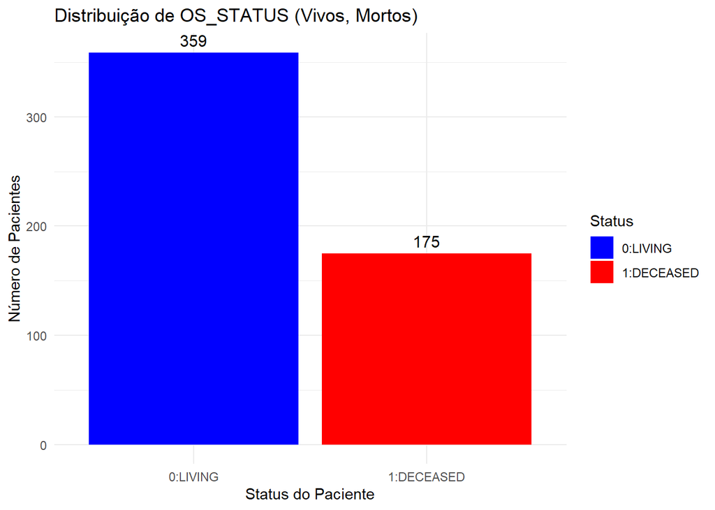

```r
status_counts <- table(amostras_metadados_limpo$OS_STATUS, useNA = "ifany")

# Converter para dataframe para o ggplot
df_status <- as.data.frame(status_counts)
colnames(df_status) <- c("Status", "Count")

# Criar o gráfico de barras
ggplot(df_status, aes(x = Status, y = Count, fill = Status)) +
  geom_bar(stat = "identity") +
  geom_text(aes(label = Count), vjust = -0.5, color = "black", size = 4) +  # Adiciona o número em cima da barra
  theme_minimal() +
  labs(title = "Distribuição de OS_STATUS (Vivos, Mortos)",
       x = "Status do Paciente",
       y = "Número de Pacientes") +
  scale_fill_manual(values = c("blue", "red", "gray"))
```

A coluna LATERALITY nos dá informações sobre o qual dos rims que está afetado por cancro em cada paciente com as respetivas denominações em inglês “Bilateral” , “Left” e “Right”. Verificou-se que o rim mais afetado era o direito (281 casos) seguido pelo esquerdo com (252 casos), que representavam a grande maioria. Com apenas 1 caso onde ambos os rins foram afetados.

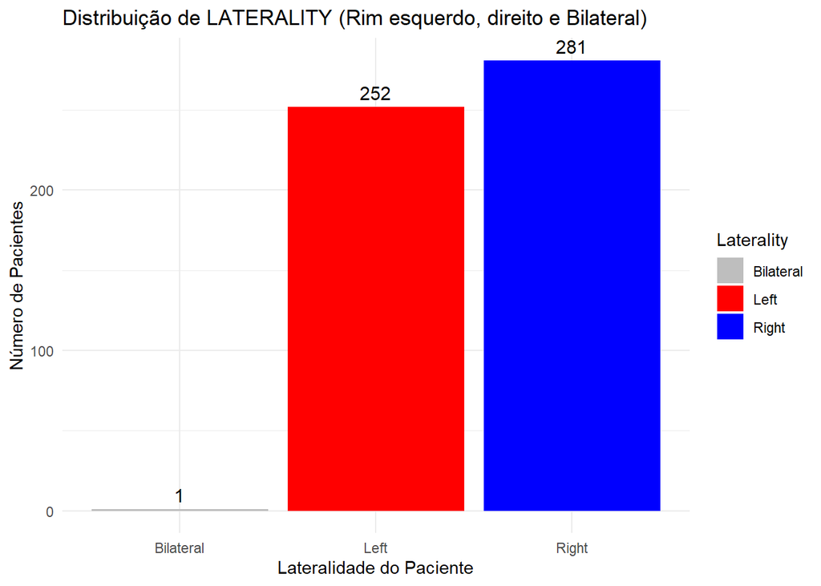

```r
laterality_counts <- table(amostras_metadados_limpo$LATERALITY, useNA = "ifany")

# Converter para dataframe para o ggplot
df_laterality <- as.data.frame(laterality_counts)
colnames(df_laterality) <- c("Laterality", "Count")

# Criar o gráfico de barras
ggplot(df_laterality, aes(x =Laterality, y = Count, fill = Laterality)) +
  geom_bar(stat = "identity") +
  geom_text(aes(label = Count), vjust = -0.5, color = "black", size = 4) +  # Adiciona o número em cima da barra
  theme_minimal() +
  labs(title = "Distribuição de LATERALITY (Rim esquerdo, direito e Bilateral)",
       x = "Lateralidade do Paciente",
       y = "Número de Pacientes") +
  scale_fill_manual(values = c("gray", "red", "blue"))
```

A coluna AGE nos informa a frequência de KIRC dependente da idade do paciente. A visualização do histograma nos permite verificar que:

A maioria dos pacientes tem entre os 50 e os 75 anos. Com um máximo atingido por volta dos 60 anos. Poucos pacientes tem menos de 40 anos ou tem mais de 85 anos. A distribuição encontra-se mais intensa para o lado direito do grafo, podendo demonstrar uma maior tendência de cancro em idadas “mais velhas”.

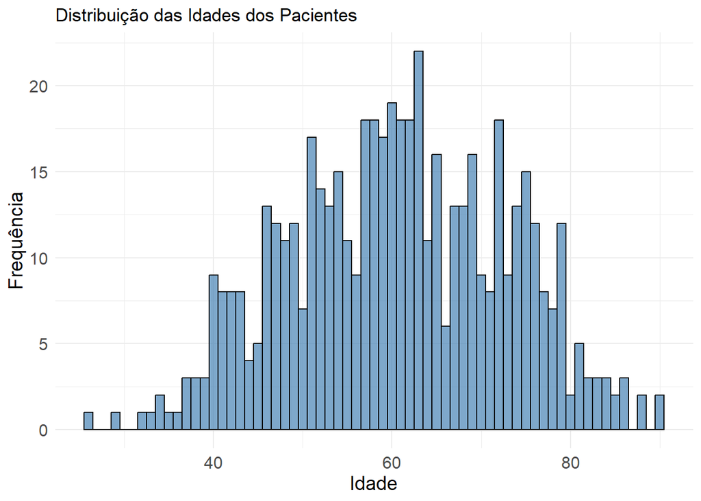

```r
#ajustavel para se perceber melhor a distribuição normal (binwidth=5)
ggplot(amostras_metadados_limpo, aes(x = AGE)) +
  geom_histogram(binwidth = 1, fill = "steelblue", color = "black", alpha = 0.7) +
  theme_minimal() +
  labs(title = "Distribuição das Idades dos Pacientes",
       x = "Idade",
       y = "Frequência") +
  theme(axis.text = element_text(size = 12),
        axis.title = element_text(size = 14))
```

A coluna SEX infere sobre o sexo dos pacientes da nossa amostra com cancro de rins. Após visualição dos gráficos percebe-se que mais da metade dos pacientes são homens (64,8%), com as mulheres a representando 35.2 % dos casos observados.

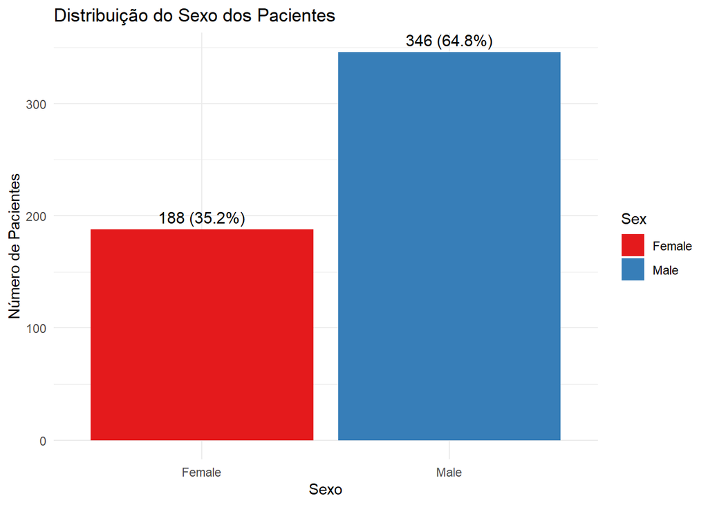

```r
#corrigir o MALE que conta como Male
amostras_metadados_limpo$SEX <- replace(amostras_metadados_limpo$SEX,
                                        amostras_metadados_limpo$SEX == "MALE",
                                        "Male")

sex_counts <- table(amostras_metadados_limpo$SEX, useNA = "ifany")

# Converter para dataframe para usar no ggplot
df_sex <- as.data.frame(sex_counts)
colnames(df_sex) <- c("Sex", "Count")

# Calcular percentagens
df_sex$Percentage <- (df_sex$Count / sum(df_sex$Count)) * 100

# Criar rótulos combinando valores absolutos e percentuais
df_sex$Label <- paste0(df_sex$Count, " (", round(df_sex$Percentage, 1), "%)")

# Criar o gráfico de barras
ggplot(df_sex, aes(x = Sex, y = Count, fill = Sex)) +
  geom_bar(stat = "identity") +
  geom_text(aes(label = Label), vjust = -0.5, color = "black", size = 4) +  # Adiciona rótulos com números e percentagens
  theme_minimal() +
  labs(title = "Distribuição do Sexo dos Pacientes",
       x = "Sexo",
       y = "Número de Pacientes") +
  scale_fill_brewer(palette = "Set1")
```

A coluna AJCC_PATHOLOGIC_TUMOR_STAGE representa o estágio de desenvolvimento tumoral de cada paciente. O estágio tumoral indica não só o quão grande é o tumor mas o quanto se espalhou pelo organismo. Associa-se principalmente com a dificuldade de remover o tumor por intervenção cirurgica. Com o aumento de cada estágio indicando maior dificuldade de remoção.

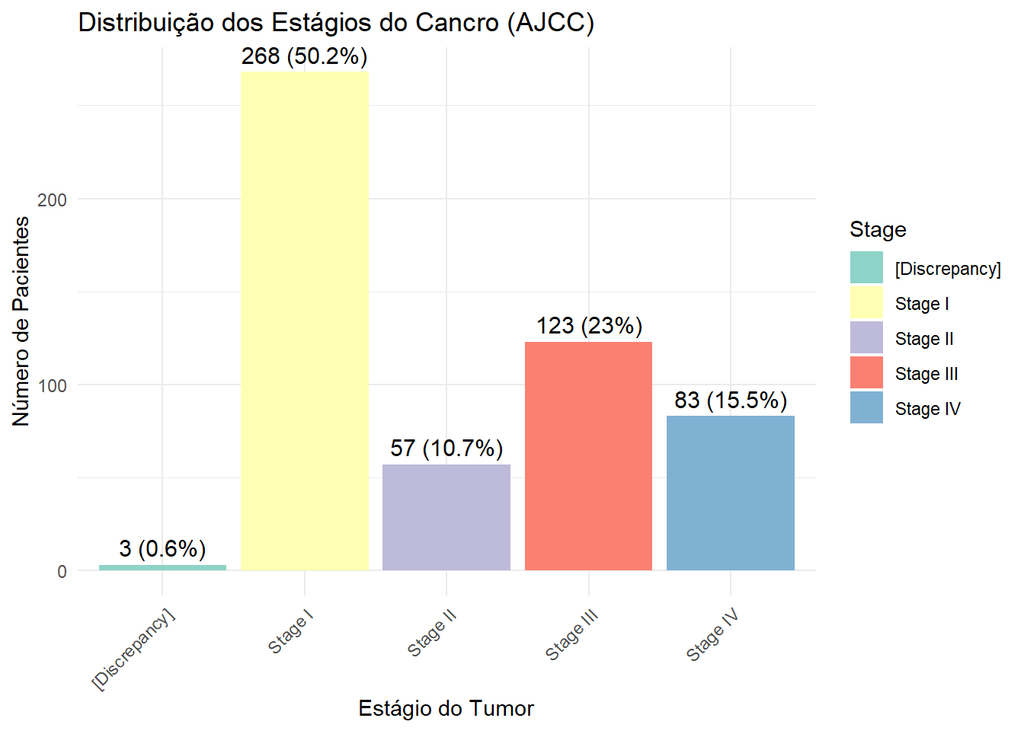

```r
stage_counts <- table(amostras_metadados_limpo$AJCC_PATHOLOGIC_TUMOR_STAGE, useNA = "ifany")

# Converter para dataframe para usar no ggplot
df_stage <- as.data.frame(stage_counts)
colnames(df_stage) <- c("Stage", "Count")

# Calcular percentagens
df_stage$Percentage <- (df_stage$Count / sum(df_stage$Count)) * 100

# Criar rótulos combinando valores absolutos e percentagens
df_stage$Label <- paste0(df_stage$Count, " (", round(df_stage$Percentage, 1), "%)")

# Criar o gráfico de barras
ggplot(df_stage, aes(x = Stage, y = Count, fill = Stage)) +
  geom_bar(stat = "identity") +
  geom_text(aes(label = Label), vjust = -0.5, color = "black", size = 4) +  # Adiciona rótulos com números e percentagens
  theme_minimal() +
  labs(title = "Distribuição dos Estágios do Cancro (AJCC)",
       x = "Estágio do Tumor",
       y = "Número de Pacientes") +
  theme(axis.text.x = element_text(angle = 45, hjust = 1)) + # Inclina os rótulos do eixo X para melhor visualização
  scale_fill_brewer(palette = "Set3")
```

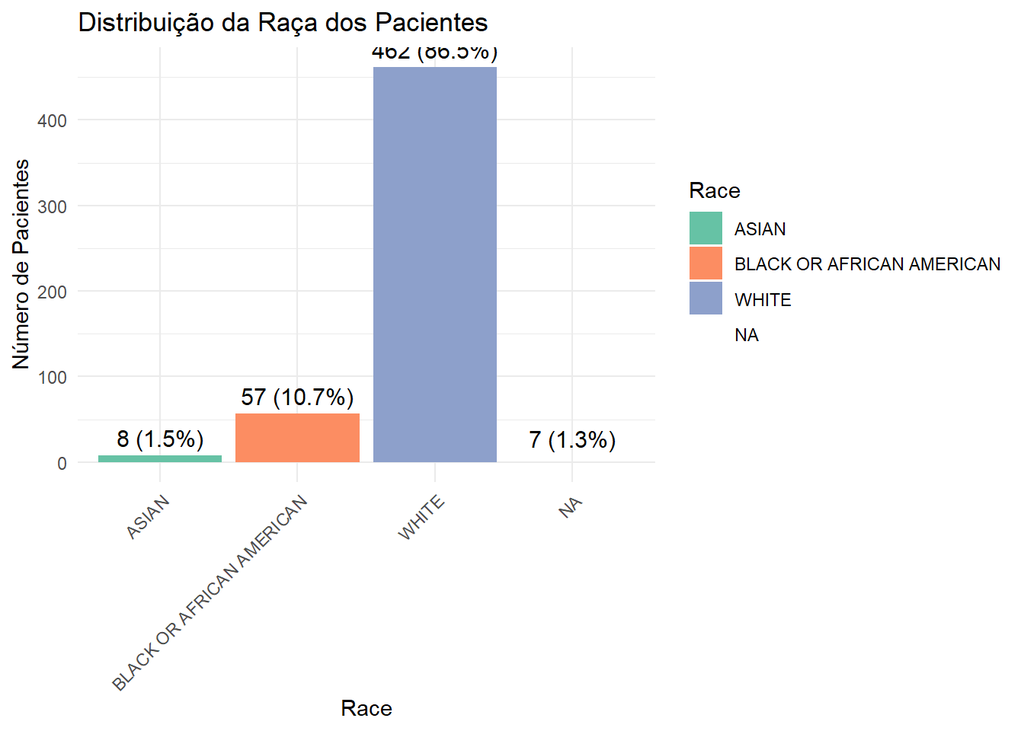

```r
race_counts <-table(amostras_metadados_limpo$RACE, useNA = "ifany")

df_race <- as.data.frame(race_counts)
colnames(df_race) <- c("Race", "Count")

# Calcular percentagens
df_race$Percentage <- (df_race$Count / sum(df_race$Count)) * 100

# Criar rótulos combinando valores absolutos e percentuais
df_race$Label <- paste0(df_race$Count, " (", round(df_race$Percentage, 1), "%)")

# Criar o gráfico de barras
ggplot(df_race, aes(x = Race, y = Count, fill = Race)) +
  geom_bar(stat = "identity") +
  geom_text(aes(label = Label), vjust = -0.5, color = "black", size = 4) +  # Adiciona rótulos com números e percentagens
  theme_minimal() +
  labs(title = "Distribuição da Raça dos Pacientes",
       y = "Número de Pacientes") +
  theme(axis.text.x = element_text(angle = 45, hjust = 1)) + # Inclina os rótulos do eixo X para melhor visualização
  scale_fill_brewer(palette = "Set2")
```

# 4. Testes de Hipótese

## 4.1 Idade por OS_STATUS

```r
# 1. Criar o modelo ANOVA
anova_result <- aov(AGE ~ OS_STATUS, data = amostras_metadados_limpo)

# 2. Obter os resíduos do modelo
residuos <- residuals(anova_result)

# 3. Teste de Shapiro-Wilk (normalidade)
shapiro.test(residuos)
```

```
##
##  Shapiro-Wilk normality test
##
## data:  residuos
## W = 0.99328, p-value = 0.01748
```

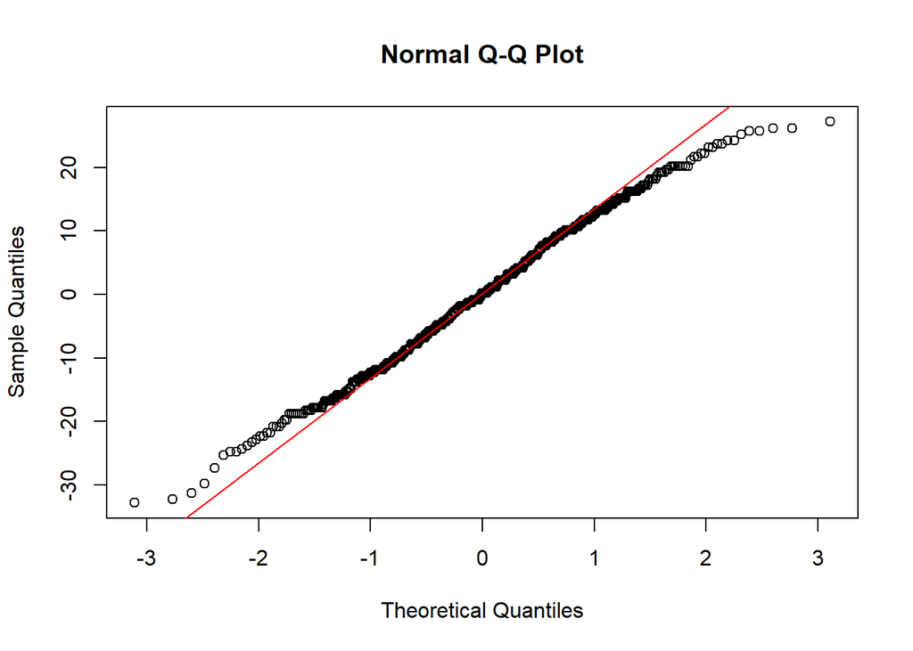

```r
# 4. QQ plot dos resíduos
qqnorm(residuos)
qqline(residuos, col = "red")
```

p-value < 0.05 → rejeitamos a hipótese nula de normalidade dos resíduos. Isso significa que os resíduos não seguem uma distribuição normal Usamos uma teste não parametrico, Mann-Whitney-Wilcoxon.

```r
wilcox.test(AGE ~ OS_STATUS, data = amostras_metadados_limpo)
```

```
##
##  Wilcoxon rank sum test with continuity correction
##
## data:  AGE by OS_STATUS
## W = 23276, p-value = 1.156e-06
## alternative hypothesis: true location shift is not equal to 0
```

O p-value é pequeno (< 0.001).

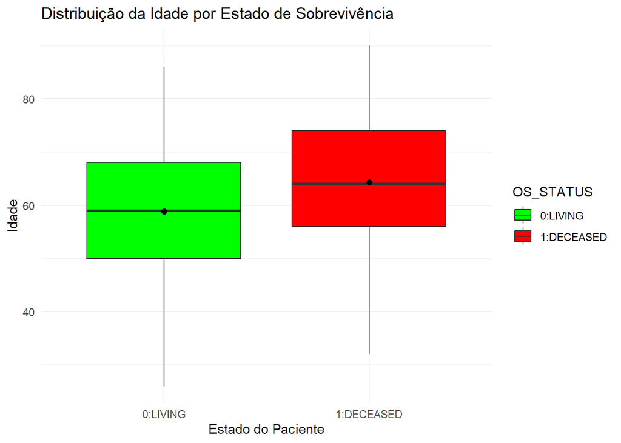

```r
# Remover NAs na idade e status
df_box <- amostras_metadados_limpo %>%
  filter(!is.na(AGE), !is.na(OS_STATUS))

# Criar gráfico de boxplot
ggplot(df_box, aes(x = OS_STATUS, y = AGE, fill = OS_STATUS)) +
  geom_boxplot() +
  theme_minimal() +
  labs(
    title = "Distribuição da Idade por Estado de Sobrevivência",
    x = "Estado do Paciente",
    y = "Idade"
  ) +
  scale_fill_manual(values = c("0:LIVING" = "green", "1:DECEASED" = "red")) +
  stat_summary(fun = mean, geom = "point", shape = 20, size = 3, color = "black", fill = "white")  # ponto da média
```

## 4.2 Idade por estágio de cancro

Apesar da distribuição para todos os outros grupos ser normal (p >0.05), o Stage III (p = 0.01969) não segue uma distribuição normal. Logo, vamos ter de recorrer a uma alternantiva não parametrica à ANOVA, o teste Kruskal-Wallis.

```r
# Verificar normalidade para cada estágio de câncer
shapiro_test <- by(amostras_metadados_limpo$AGE, amostras_metadados_limpo$AJCC_PATHOLOGIC_TUMOR_STAGE, shapiro.test)
shapiro_test
```

```
## amostras_metadados_limpo$AJCC_PATHOLOGIC_TUMOR_STAGE: [Discrepancy]
##
##  Shapiro-Wilk normality test
##
## data:  dd[x, ]
## W = 0.96429, p-value = 0.6369
##
## ------------------------------------------------------------
## amostras_metadados_limpo$AJCC_PATHOLOGIC_TUMOR_STAGE: Stage I
##
##  Shapiro-Wilk normality test
##
## data:  dd[x, ]
## W = 0.99013, p-value = 0.06641
##
## ------------------------------------------------------------
## amostras_metadados_limpo$AJCC_PATHOLOGIC_TUMOR_STAGE: Stage II
##
##  Shapiro-Wilk normality test
##
## data:  dd[x, ]
## W = 0.96648, p-value = 0.1148
##
## ------------------------------------------------------------
## amostras_metadados_limpo$AJCC_PATHOLOGIC_TUMOR_STAGE: Stage III
##
##  Shapiro-Wilk normality test
##
## data:  dd[x, ]
## W = 0.9745, p-value = 0.01969
##
## ------------------------------------------------------------
## amostras_metadados_limpo$AJCC_PATHOLOGIC_TUMOR_STAGE: Stage IV
##
##  Shapiro-Wilk normality test
##
## data:  dd[x, ]
## W = 0.98941, p-value = 0.737
```

O p-value é < 0.05 –> logo rejeitamos a hipotese nula, existe pelo menos uma diferença estatisticamente significativa na idade dos pacientes entre os diferentes estágios de cancro.

```r
kruskal.test(AGE ~ AJCC_PATHOLOGIC_TUMOR_STAGE, data = amostras_metadados_limpo)
```

```
##
##  Kruskal-Wallis rank sum test
##
## data:  AGE by AJCC_PATHOLOGIC_TUMOR_STAGE
## Kruskal-Wallis chi-squared = 10.228, df = 4, p-value = 0.03676
```

```r
# Teste de Kruskal-Wallis (como já usas)
kruskal.test(AGE ~ AJCC_PATHOLOGIC_TUMOR_STAGE, data = amostras_metadados_limpo)
```

```
##
##  Kruskal-Wallis rank sum test
##
## data:  AGE by AJCC_PATHOLOGIC_TUMOR_STAGE
## Kruskal-Wallis chi-squared = 10.228, df = 4, p-value = 0.03676
```

```r
# Comparação múltipla post-hoc com correção de Bonferroni
pairwise.wilcox.test(amostras_metadados_limpo$AGE,
                     amostras_metadados_limpo$AJCC_PATHOLOGIC_TUMOR_STAGE,
                     p.adjust.method = "bonferroni")
```

```
##
##  Pairwise comparisons using Wilcoxon rank sum test with continuity correction
##
## data:  amostras_metadados_limpo$AGE and amostras_metadados_limpo$AJCC_PATHOLOGIC_TUMOR_STAGE
##
##           [Discrepancy] Stage I Stage II Stage III
## Stage I   1.00          -       -        -
## Stage II  1.00          1.00    -        -
## Stage III 1.00          0.04    0.43     -
## Stage IV  1.00          1.00    1.00     0.18
##
## P value adjustment method: bonferroni
```

Não se verificou nenhuma diferença significativa entre os diferentes estágios (p>0.05) com exceção dos pacientes no estágio III têm, em média, idades significativamente diferentes dos do estágio I.

A visualização deixa claro que as medianas não parecem ter diferenças significativas entre a idade nos diversos estágios.

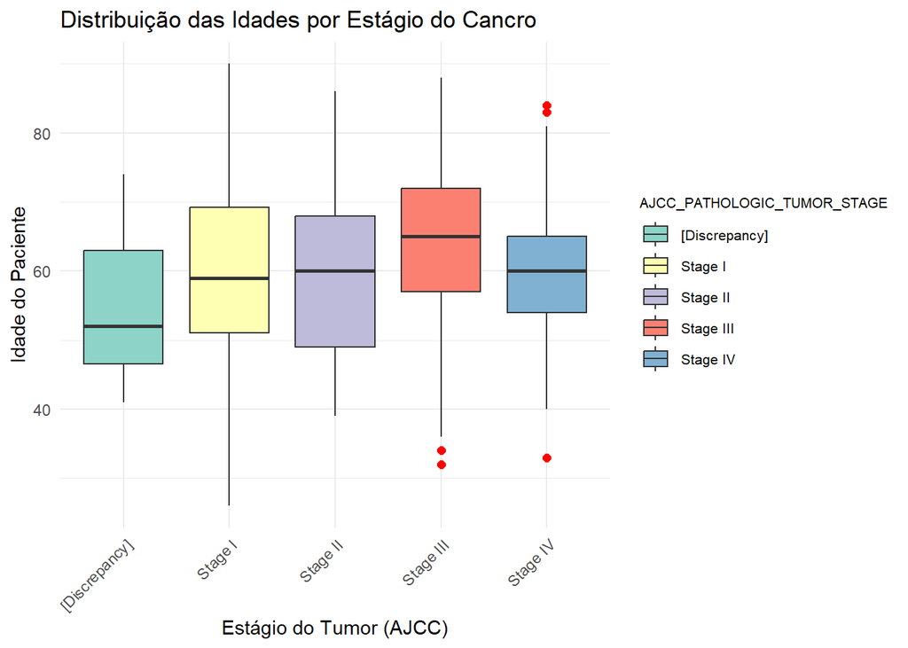

```r
# Boxplot das idades por estágio do cancro
ggplot(amostras_metadados_limpo, aes(x = AJCC_PATHOLOGIC_TUMOR_STAGE, y = AGE, fill = AJCC_PATHOLOGIC_TUMOR_STAGE)) +
  geom_boxplot(outlier.colour = "red", outlier.shape = 16, outlier.size = 2) +
  theme_minimal() +
  labs(title = "Distribuição das Idades por Estágio do Cancro",
       x = "Estágio do Tumor (AJCC)",
       y = "Idade do Paciente") +
  theme(axis.text.x = element_text(angle = 45, hjust = 1),
        legend.title = element_text(size = 8),
        legend.text = element_text(size = 8)) +  # Diminui o texto da legenda
  scale_fill_brewer(palette = "Set3")
```

## 4.3 **Distribuição da sobrevivência (OS_MONTHS)** por **estágio do tumor (AJCC_PATHOLOGIC_TUMOR_STAGE)**

Testar a normalidade

```r
normality_test <- amostras_metadados_limpo %>%
  group_by(AJCC_PATHOLOGIC_TUMOR_STAGE) %>%
  summarise(shapiro_test = list(shapiro.test(OS_MONTHS))) %>%
  mutate(shapiro_p_value = sapply(shapiro_test, function(x) x$p.value))

print(normality_test)
```

```
## # A tibble: 5 × 3
##   AJCC_PATHOLOGIC_TUMOR_STAGE shapiro_test shapiro_p_value
##   <chr>                       <list>                 <dbl>
## 1 Stage I                     <htest>         0.000000623
## 2 Stage II                    <htest>         0.118
## 3 Stage III                   <htest>         0.00000476
## 4 Stage IV                    <htest>         0.0000000913
## 5 [Discrepancy]               <htest>         0.770
```

- **Stage I** (p-value = 6.23e-07): Não é normal.
- **Stage II** (p-value = 0.1183): A distribuição é aproximadamente normal.
- **Stage III** (p-value = 4.76e-06): Não é normal.
- **Stage IV** (p-value = 9.13e-08): Não é normal.

Logo usamos um teste não parametrico, o kruskal-Wallis.

```r
kruskal.test(OS_MONTHS ~ AJCC_PATHOLOGIC_TUMOR_STAGE, data = amostras_metadados_limpo)
```

```
##
##  Kruskal-Wallis rank sum test
##
## data:  OS_MONTHS by AJCC_PATHOLOGIC_TUMOR_STAGE
## Kruskal-Wallis chi-squared = 22.467, df = 4, p-value = 0.0001618
```

p-value < 0.05 significa que há diferença significativa entre estagios de grupo em relação a distribuição de sobrevivencia (OS_MONTHS)

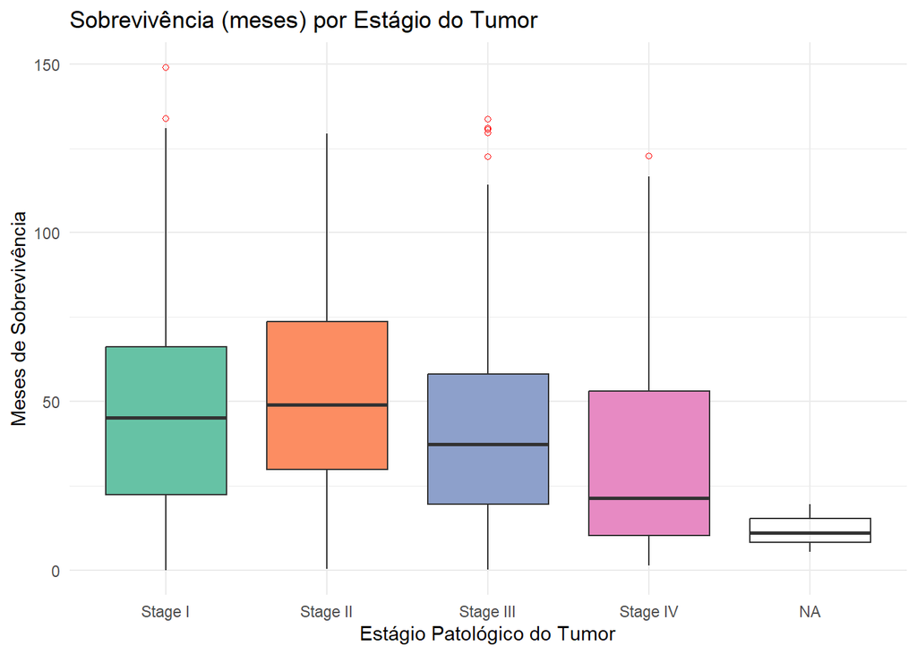

```r
# Garantir que o estágio está como fator e ordenado corretamente (opcional mas melhora visual)
amostras_metadados_limpo$AJCC_PATHOLOGIC_TUMOR_STAGE <- factor(
  amostras_metadados_limpo$AJCC_PATHOLOGIC_TUMOR_STAGE,
  levels = c("Stage I", "Stage II", "Stage III", "Stage IV")
)

# Criar o boxplot
ggplot(amostras_metadados_limpo, aes(x = AJCC_PATHOLOGIC_TUMOR_STAGE, y = OS_MONTHS, fill = AJCC_PATHOLOGIC_TUMOR_STAGE)) +
  geom_boxplot(outlier.color = "red", outlier.shape = 1) +
  theme_minimal() +
  labs(title = "Sobrevivência (meses) por Estágio do Tumor",
       x = "Estágio Patológico do Tumor",
       y = "Meses de Sobrevivência") +
  scale_fill_brewer(palette = "Set2") +
  theme(legend.position = "none")  # Remove legenda se quiseres economizar espaço
```

## 4.4 Proporção de pacientes vivos/mortos por estágio

Como é de se esperar, quanto mais aumentamos o estágio do KIRC maior a taxa de óbito.

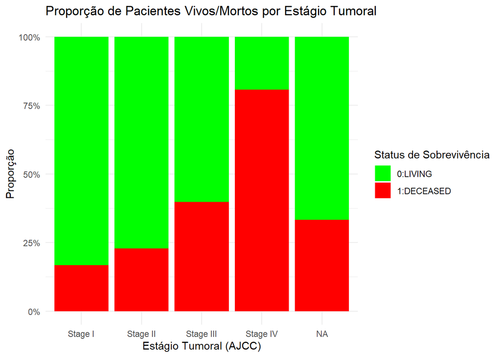

```r
# Verifica se OS_STATUS e AJCC_PATHOLOGIC_TUMOR_STAGE estão como fator
amostras_metadados_limpo$OS_STATUS <- factor(amostras_metadados_limpo$OS_STATUS, levels = c("0:LIVING", "1:DECEASED"))
amostras_metadados_limpo$AJCC_PATHOLOGIC_TUMOR_STAGE <- factor(amostras_metadados_limpo$AJCC_PATHOLOGIC_TUMOR_STAGE)

# Gráfico de barras empilhado em proporção
ggplot(amostras_metadados_limpo, aes(x = AJCC_PATHOLOGIC_TUMOR_STAGE, fill = OS_STATUS)) +
  geom_bar(position = "fill") +
  scale_y_continuous(labels = scales::percent) +
  labs(
    title = "Proporção de Pacientes Vivos/Mortos por Estágio Tumoral",
    x = "Estágio Tumoral (AJCC)",
    y = "Proporção",
    fill = "Status de Sobrevivência"
  ) +
  scale_fill_manual(values = c("0:LIVING" = "green", "1:DECEASED" = "red")) +
  theme_minimal()
```

Teste para ver se o estágio está associado ao status de sobrevivência:

```r
tabela <- table(amostras_metadados_limpo$AJCC_PATHOLOGIC_TUMOR_STAGE, amostras_metadados_limpo$OS_STATUS)

# Teste do Qui-quadrado
chisq.test(tabela)
```

```
##
##  Pearson's Chi-squared test
##
## data:  tabela
## X-squared = 123.05, df = 3, p-value < 2.2e-16
```

Indica que há uma associação estatisticamente significativa entre o estágio do tumor e o status de sobrevivência

## 4.5 Comparação de dimensão do tumor:

### Com o status:

Testar a normalidade

```r
#tranformar em numero
amostras_metadados_limpo$LONGEST_DIMENSION <- as.numeric(as.character(amostras_metadados_limpo$LONGEST_DIMENSION))

grupos_status <- split(amostras_metadados_limpo$LONGEST_DIMENSION, amostras_metadados_limpo$OS_STATUS)
lapply(grupos_status, shapiro.test)
```

```
## $`0:LIVING`
##
##  Shapiro-Wilk normality test
##
## data:  X[[i]]
## W = 0.87987, p-value = 2.585e-15
##
##
## $`1:DECEASED`
##
##  Shapiro-Wilk normality test
##
## data:  X[[i]]
## W = 0.959, p-value = 6.579e-05
```

Ambos os grupos não têm uma distribuição normal, é mais adequado utilizar testes não paramétricos (Mann-Whitney) para comparar a dimensão do tumor entre os dois grupos (vivos vs. falecidos).

```r
wilcox.test(LONGEST_DIMENSION ~ OS_STATUS, data = amostras_metadados_limpo)
```

```
##
##  Wilcoxon rank sum test with continuity correction
##
## data:  LONGEST_DIMENSION by OS_STATUS
## W = 20374, p-value = 6.149e-07
## alternative hypothesis: true location shift is not equal to 0
```

p-value < 0.05 logo podemos concluir que existe uma diferença estatisticamente significativa entre as dimensões do tumor em pacientes vivos e mortos.

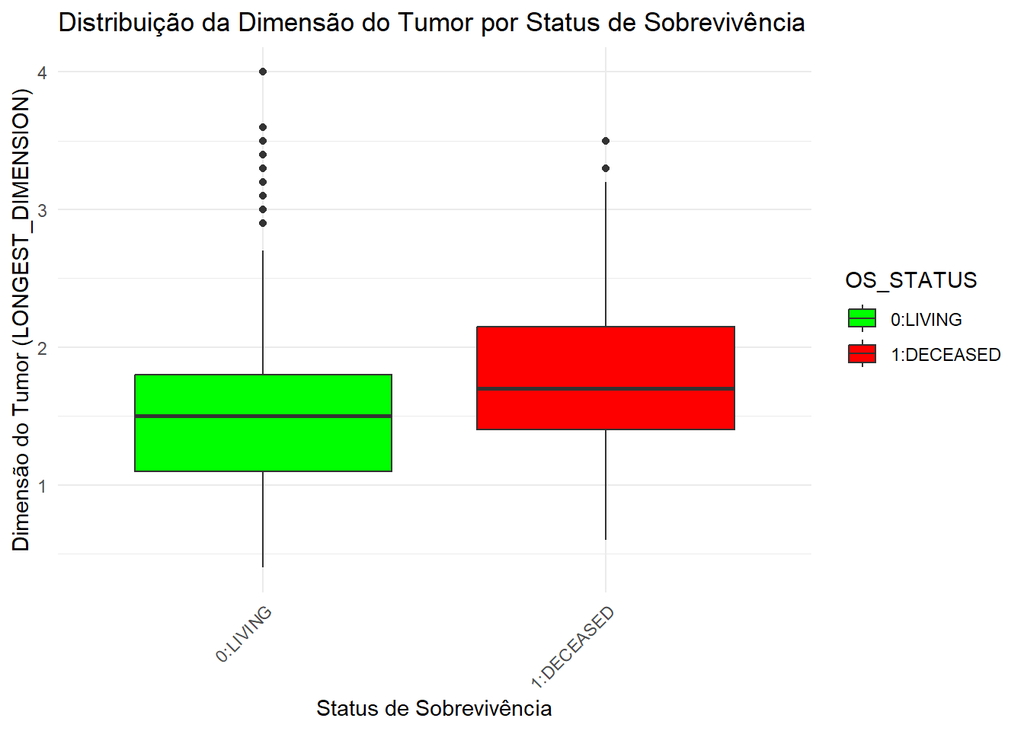

```r
ggplot(amostras_metadados_limpo, aes(x = OS_STATUS, y = LONGEST_DIMENSION, fill = OS_STATUS)) +
  geom_boxplot() +
  scale_fill_manual(values = c("0:LIVING" = "green", "1:DECEASED" = "red")) +  # Definir cores específicas
  labs(title = "Distribuição da Dimensão do Tumor por Status de Sobrevivência",
       x = "Status de Sobrevivência",
       y = "Dimensão do Tumor (LONGEST_DIMENSION)") +
  theme_minimal() +
  theme(axis.text.x = element_text(angle = 45, hjust = 1))
```

### Com o estágio:

Testar a normalidade

```r
grupos_estagio <- split(amostras_metadados_limpo$LONGEST_DIMENSION, amostras_metadados_limpo$AJCC_PATHOLOGIC_TUMOR_STAGE)
lapply(grupos_estagio, shapiro.test)
```

```
## $`Stage I`
##
##  Shapiro-Wilk normality test
##
## data:  X[[i]]
## W = 0.89465, p-value = 5.755e-12
##
##
## $`Stage II`
##
##  Shapiro-Wilk normality test
##
## data:  X[[i]]
## W = 0.91187, p-value = 0.0008414
##
##
## $`Stage III`
##
##  Shapiro-Wilk normality test
##
## data:  X[[i]]
## W = 0.93319, p-value = 1.417e-05
##
##
## $`Stage IV`
##
##  Shapiro-Wilk normality test
##
## data:  X[[i]]
## W = 0.94041, p-value = 0.001013
```

Todos os valores de p são significativamente pequenos (muito abaixo de 0,05), indicando que a normalidade é rejeitada. Logo usamos o teste não parametrico Kruskal.

```r
kruskal.test(LONGEST_DIMENSION ~ AJCC_PATHOLOGIC_TUMOR_STAGE, data = amostras_metadados_limpo)
```

```
##
##  Kruskal-Wallis rank sum test
##
## data:  LONGEST_DIMENSION by AJCC_PATHOLOGIC_TUMOR_STAGE
## Kruskal-Wallis chi-squared = 30.535, df = 3, p-value = 1.065e-06
```

```r
# Remover as linhas com valores ausentes para LONGEST_DIMENSION ou AJCC_PATHOLOGIC_TUMOR_STAGE
amostras_metadados_limpo_sem_na <- amostras_metadados_limpo[!is.na(amostras_metadados_limpo$LONGEST_DIMENSION) & !is.na(amostras_metadados_limpo$AJCC_PATHOLOGIC_TUMOR_STAGE), ]

pairwise.wilcox.test(amostras_metadados_limpo_sem_na$LONGEST_DIMENSION,
                     amostras_metadados_limpo_sem_na$AJCC_PATHOLOGIC_TUMOR_STAGE,
                     p.adjust.method = "bonferroni")
```

```
##
##  Pairwise comparisons using Wilcoxon rank sum test with continuity correction
##
## data:  amostras_metadados_limpo_sem_na$LONGEST_DIMENSION and amostras_metadados_limpo_sem_na$AJCC_PATHOLOGIC_TUMOR_STAGE
##
##           Stage I Stage II Stage III
## Stage II  0.6482  -        -
## Stage III 0.0036  1.0000   -
## Stage IV  1.5e-06 0.1604   0.3182
##
## P value adjustment method: bonferroni
```

Só há diferenças estatisticamente significativas apenas entre Stage I e Stage III/IV.

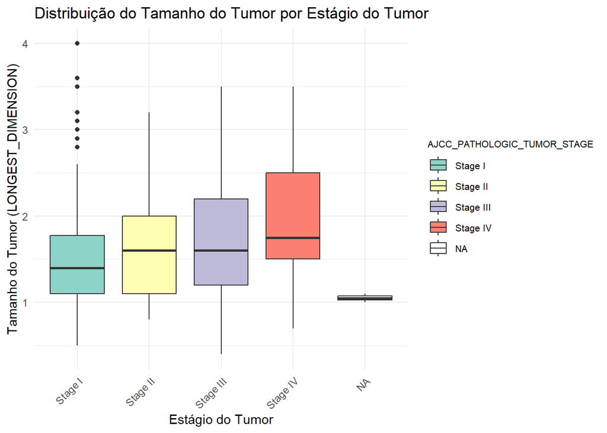

```r
ggplot(amostras_metadados_limpo, aes(x = AJCC_PATHOLOGIC_TUMOR_STAGE, y = LONGEST_DIMENSION, fill = AJCC_PATHOLOGIC_TUMOR_STAGE)) +
  geom_boxplot() +
  labs(title = "Distribuição do Tamanho do Tumor por Estágio do Tumor",
       x = "Estágio do Tumor",
       y = "Tamanho do Tumor (LONGEST_DIMENSION)") +
  scale_fill_brewer(palette = "Set3") +  # Altere a paleta se preferir outras cores
  theme_minimal() +
  theme(axis.text.x = element_text(angle = 45, hjust = 1),  # Inclina os rótulos do eixo X
        legend.text = element_text(size = 8),  # Diminui o tamanho do texto da legenda
        legend.title = element_text(size = 8))  # Diminui o tamanho do título da legenda
```

## 4.6 Correlação entre AGE e OS_MONTHS

testar a normalidade dos residuos

```r
# Verificar NAs e Inf
sum(is.na(amostras_metadados_limpo$OS_MONTHS))  # Contagem de NAs em OS_MONTHS
```

```
## [1] 0
```

```r
sum(is.infinite(amostras_metadados_limpo$OS_MONTHS))  # Contagem de Inf em OS_MONTHS
```

```
## [1] 0
```

```r
sum(amostras_metadados_limpo$OS_MONTHS <= 0, na.rm = TRUE)  # Contagem de valores <= 0 em OS_MONTHS
```

```
## [1] 2
```

```r
# Substituir ou remover valores inválidos
amostras_metadados_limpo <- amostras_metadados_limpo[amostras_metadados_limpo$OS_MONTHS > 0, ]

# Criar o modelo com a transformação log
modelo_log <- lm(log(OS_MONTHS) ~ AGE, data = amostras_metadados_limpo)
summary(modelo_log)
```

```
##
## Call:
## lm(formula = log(OS_MONTHS) ~ AGE, data = amostras_metadados_limpo)
##
## Residuals:
##     Min      1Q  Median      3Q     Max
## -5.8658 -0.5031  0.3273  0.7866  1.6875
##
## Coefficients:
##              Estimate Std. Error t value Pr(>|t|)
## (Intercept)  3.967734   0.264532  14.999   <2e-16 ***
## AGE         -0.010015   0.004281  -2.339   0.0197 *
## ---
## Signif. codes:  0 '***' 0.001 '**' 0.01 '*' 0.05 '.' 0.1 ' ' 1
##
## Residual standard error: 1.198 on 530 degrees of freedom
## Multiple R-squared:  0.01022,    Adjusted R-squared:  0.008351
## F-statistic: 5.472 on 1 and 530 DF,  p-value: 0.0197
```

```r
#testar a normalidade
shapiro.test(residuals(modelo_log))
```

```
##
##  Shapiro-Wilk normality test
##
## data:  residuals(modelo_log)
## W = 0.86461, p-value < 2.2e-16
```

```r
#testar se a variância dos resíduos não for constante (heterocedasticidade)
anova(modelo_log)
```

```
## Analysis of Variance Table
##
## Response: log(OS_MONTHS)
##            Df Sum Sq Mean Sq F value Pr(>F)
## AGE         1   7.85  7.8504  5.4716 0.0197 *
## Residuals 530 760.41  1.4347
## ---
## Signif. codes:  0 '***' 0.001 '**' 0.01 '*' 0.05 '.' 0.1 ' ' 1
```

p-value <0.05 sugere que **os resíduos não seguem uma distribuição normal**.

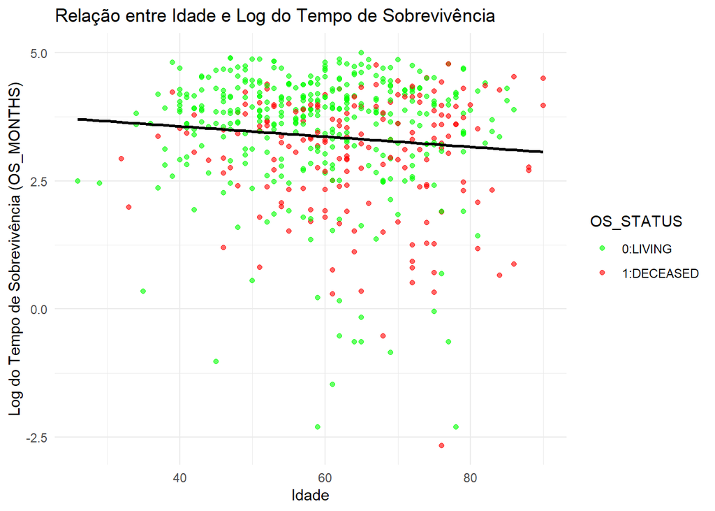

```r
ggplot(amostras_metadados_limpo, aes(x = AGE, y = log(OS_MONTHS), color = OS_STATUS)) +
  geom_point(alpha = 0.6) +  # Plota os pontos
  geom_smooth(method = "lm", se = FALSE, color = "black") +  # Adiciona a linha de regressão
  labs(title = "Relação entre Idade e Log do Tempo de Sobrevivência",
       x = "Idade",
       y = "Log do Tempo de Sobrevivência (OS_MONTHS)") +
  theme_minimal() +
  scale_color_manual(values = c("green", "red"))  # Vivos em verde, falecidos em vermelho
```

# 5. Análise Genómica

Neste relatório é realizada uma análise completa dos dados de expressão RNA-Seq do projeto TCGA-KIRC. Utilizamos múltiplos métodos para identificar genes diferencialmente expressos e analisamos a sua relevância biológica através de enriquecimento funcional.

## 5.1 Load dos Dados RNA-Seq

O download dos dados já foi feito préviamente, através do GDCdownload da query (data.category = “Transcriptome Profiling”, data.type = “Gene Expression Quantification”, workflow.type = “STAR - Counts”).

```r
load("dados_tcga.rda")
```

## 5.2. DESeq2 - Expressão Diferencial

```r
counts <- assay(data)
colData <- colData(data)
dds <- DESeqDataSetFromMatrix(countData = counts, colData = colData, design = ~ vital_status)
dds <- dds[rowSums(counts(dds)) >= 10, ]
dds <- DESeq(dds)
res_deseq <- results(dds)
summary(res_deseq)
```

```
##
## out of 56263 with nonzero total read count
## adjusted p-value < 0.1
## LFC > 0 (up)       : 11799, 21%
## LFC < 0 (down)     : 7736, 14%
## outliers [1]       : 0, 0%
## low counts [2]     : 11999, 21%
## (mean count < 0)
## [1] see 'cooksCutoff' argument of ?results
## [2] see 'independentFiltering' argument of ?results
```

```r
geneExp_df <- as.data.frame(geneExp)
```

## 5.3. Volcano Plot (DESeq2)

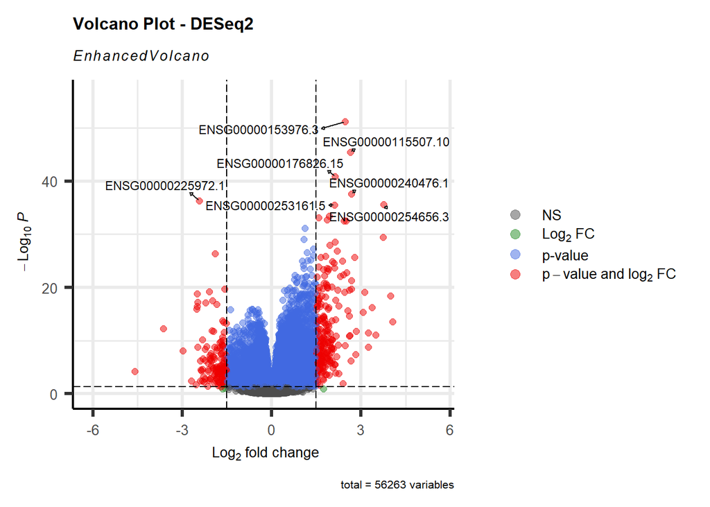

```r
EnhancedVolcano(res_deseq,
    lab = rownames(res_deseq),
    x = 'log2FoldChange',
    y = 'pvalue',
    title = 'Volcano Plot - DESeq2',
    pCutoff = 0.05,
    FCcutoff = 1.5,
    pointSize = 2.0,
    labSize = 3.0,
    max.overlaps = 10,
    legendPosition = 'right',
    legendLabSize = 10,
    legendIconSize = 3.0,
    drawConnectors = TRUE,
    widthConnectors = 0.5,
    axisLabSize = 10,
    titleLabSize = 12,
    subtitleLabSize = 10,
    captionLabSize = 8
)
```

**Eixo X (log2FoldChange)**: Mostra a magnitude da mudança na expressão gênica.

- Valores negativos: genes subexpressos (downregulated) no grupo de interesse.
- Valores positivos: genes sobre-expressos (upregulated) no grupo de interesse.

**Eixo Y (-log10(p-value))**: Mostra a significância estatística.

- Quanto mais alto, mais significativo (menor p-valor).

```r
top_genes <- rownames(head(res_deseq[order(res_deseq$pvalue), ], 5))
top_genes
```

```
## [1] "ENSG00000153976.3"  "ENSG00000115507.10" "ENSG00000176826.15"
## [4] "ENSG00000240476.1"  "ENSG00000225972.1"
```

“ENSG00000153976.3” “ENSG00000115507.10” “ENSG00000176826.15” “ENSG00000240476.1” São sobre-expressos.

“ENSG00000225972.1” É subexpresso.

## 5.4. Heatmap dos Top 30 Genes (DESeq2)

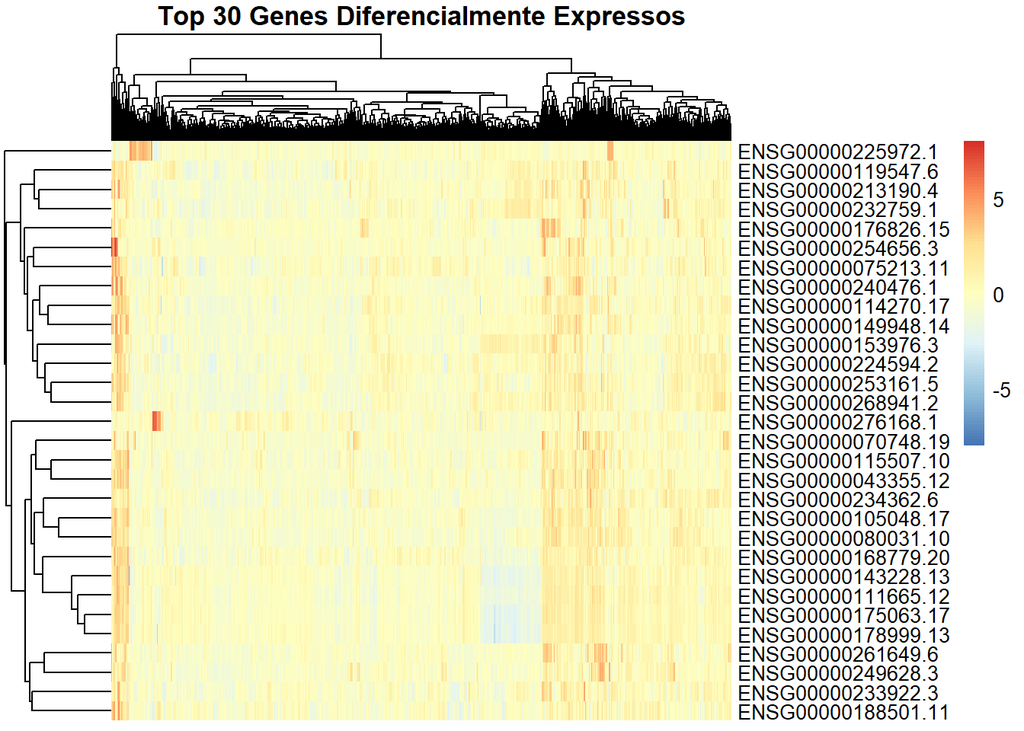

```r
top_genes <- head(order(res_deseq$pvalue), 30)
mat <- counts(dds, normalized=TRUE)[top_genes, ]
mat <- log2(mat + 1)
pheatmap(mat, show_rownames=TRUE, show_colnames=FALSE, scale="row",
         main="Top 30 Genes Diferencialmente Expressos")
```

Através de múltiplas abordagens (DESeq2, edgeR, limma), identificámos genes diferencialmente expressos entre amostras de KIRC. A análise de enriquecimento revelou processos biológicos e vias celulares relevantes, permitindo uma compreensão mais profunda do papel destes genes na fisiopatologia do carcinoma renal.

# Parte 2

# 6. Analise não supervisionada

## 6.1 PCA

```r
geneExp_df <- as.data.frame(geneExp)   #pra que que serve essa parte ?

# Transpor dados: genes nas linhas, amostras nas colunas
dados_pca <- t(geneExp_df)

# PCA sem normalizar, porque já são valores normalizados de expressão
pcares <- prcomp(dados_pca, scale = FALSE)

# Variância explicada cumulativa
summary(pcares)$importance[3, ]
```

```
##     PC1     PC2     PC3     PC4     PC5     PC6     PC7     PC8     PC9    PC10
## 0.14226 0.24105 0.32065 0.38003 0.43304 0.47942 0.51974 0.55688 0.59315 0.62300
##    PC11    PC12    PC13    PC14    PC15    PC16    PC17    PC18    PC19    PC20
## 0.64623 0.66679 0.68657 0.70217 0.71734 0.73198 0.74608 0.75885 0.77114 0.78222
##    PC21    PC22    PC23    PC24    PC25    PC26    PC27    PC28    PC29    PC30
## 0.79221 0.80158 0.80959 0.81706 0.82417 0.83083 0.83714 0.84331 0.84893 0.85422
##    PC31    PC32    PC33    PC34    PC35    PC36    PC37    PC38    PC39    PC40
## 0.85903 0.86362 0.86796 0.87217 0.87593 0.87964 0.88303 0.88603 0.88893 0.89178
##    PC41    PC42    PC43    PC44    PC45    PC46    PC47    PC48    PC49    PC50
## 0.89455 0.89710 0.89949 0.90179 0.90408 0.90631 0.90849 0.91052 0.91249 0.91441
##    PC51    PC52    PC53    PC54    PC55    PC56    PC57    PC58    PC59    PC60
## 0.91623 0.91801 0.91979 0.92144 0.92308 0.92466 0.92618 0.92768 0.92911 0.93053
##    PC61    PC62    PC63    PC64    PC65    PC66    PC67    PC68    PC69    PC70
## 0.93184 0.93311 0.93436 0.93556 0.93675 0.93791 0.93905 0.94015 0.94123 0.94227
##    PC71    PC72    PC73    PC74    PC75    PC76    PC77    PC78    PC79    PC80
## 0.94330 0.94428 0.94526 0.94622 0.94716 0.94808 0.94895 0.94980 0.95062 0.95142
##    PC81    PC82    PC83    PC84    PC85    PC86    PC87    PC88    PC89    PC90
## 0.95221 0.95298 0.95373 0.95447 0.95518 0.95588 0.95657 0.95724 0.95790 0.95854
##    PC91    PC92    PC93    PC94    PC95    PC96    PC97    PC98    PC99   PC100
## 0.95918 0.95981 0.96042 0.96102 0.96161 0.96219 0.96274 0.96328 0.96382 0.96434
##   PC101   PC102   PC103   PC104   PC105   PC106   PC107   PC108   PC109   PC110
## 0.96486 0.96537 0.96586 0.96635 0.96683 0.96729 0.96775 0.96821 0.96866 0.96910
##   PC111   PC112   PC113   PC114   PC115   PC116   PC117   PC118   PC119   PC120
## 0.96953 0.96995 0.97036 0.97077 0.97117 0.97157 0.97196 0.97235 0.97272 0.97309
##   PC121   PC122   PC123   PC124   PC125   PC126   PC127   PC128   PC129   PC130
## 0.97345 0.97381 0.97416 0.97451 0.97485 0.97518 0.97551 0.97583 0.97615 0.97646
##   PC131   PC132   PC133   PC134   PC135   PC136   PC137   PC138   PC139   PC140
## 0.97677 0.97707 0.97737 0.97766 0.97795 0.97823 0.97850 0.97877 0.97904 0.97931
##   PC141   PC142   PC143   PC144   PC145   PC146   PC147   PC148   PC149   PC150
## 0.97957 0.97982 0.98007 0.98032 0.98056 0.98080 0.98103 0.98126 0.98149 0.98171
##   PC151   PC152   PC153   PC154   PC155   PC156   PC157   PC158   PC159   PC160
## 0.98194 0.98216 0.98237 0.98258 0.98280 0.98300 0.98321 0.98341 0.98361 0.98380
##   PC161   PC162   PC163   PC164   PC165   PC166   PC167   PC168   PC169   PC170
## 0.98399 0.98418 0.98437 0.98455 0.98473 0.98491 0.98509 0.98526 0.98543 0.98560
##   PC171   PC172   PC173   PC174   PC175   PC176   PC177   PC178   PC179   PC180
## 0.98577 0.98593 0.98609 0.98625 0.98640 0.98656 0.98671 0.98686 0.98701 0.98715
##   PC181   PC182   PC183   PC184   PC185   PC186   PC187   PC188   PC189   PC190
## 0.98730 0.98744 0.98758 0.98772 0.98786 0.98799 0.98813 0.98826 0.98838 0.98851
##   PC191   PC192   PC193   PC194   PC195   PC196   PC197   PC198   PC199   PC200
## 0.98864 0.98876 0.98889 0.98901 0.98913 0.98924 0.98936 0.98948 0.98959 0.98971
```

[output cut: 53 more lines]

```
## 0.99955 0.99956 0.99957 0.99958 0.99959 0.99960 0.99961 0.99961 0.99962 0.99963
##   PC471   PC472   PC473   PC474   PC475   PC476   PC477   PC478   PC479   PC480
## 0.99964 0.99965 0.99965 0.99966 0.99967 0.99968 0.99969 0.99969 0.99970 0.99971
##   PC481   PC482   PC483   PC484   PC485   PC486   PC487   PC488   PC489   PC490
## 0.99972 0.99972 0.99973 0.99974 0.99974 0.99975 0.99976 0.99977 0.99977 0.99978
##   PC491   PC492   PC493   PC494   PC495   PC496   PC497   PC498   PC499   PC500
## 0.99979 0.99979 0.99980 0.99981 0.99981 0.99982 0.99982 0.99983 0.99984 0.99984
##   PC501   PC502   PC503   PC504   PC505   PC506   PC507   PC508   PC509   PC510
## 0.99985 0.99985 0.99986 0.99987 0.99987 0.99988 0.99988 0.99989 0.99989 0.99990
##   PC511   PC512   PC513   PC514   PC515   PC516   PC517   PC518   PC519   PC520
## 0.99990 0.99991 0.99991 0.99992 0.99992 0.99993 0.99993 0.99994 0.99994 0.99995
##   PC521   PC522   PC523   PC524   PC525   PC526   PC527   PC528   PC529   PC530
## 0.99995 0.99996 0.99996 0.99997 0.99997 0.99998 0.99998 0.99998 0.99999 0.99999
##   PC531   PC532   PC533   PC534
## 1.00000 1.00000 1.00000 1.00000
```

```r
# Número de componentes necessárias para explicar pelo menos 95% da variância
min(which(summary(pcares)$importance[3, ] > 0.95))
```

```
## [1] 79
```

No nosso caso, observou-se que, das mais de 200 mil variáveis, seriam necessárias 79 de componentes principais para explicar 95% da variabilidade dos dados. No entanto, os dois primeiros componentes já representam uma fração relevante da variância.

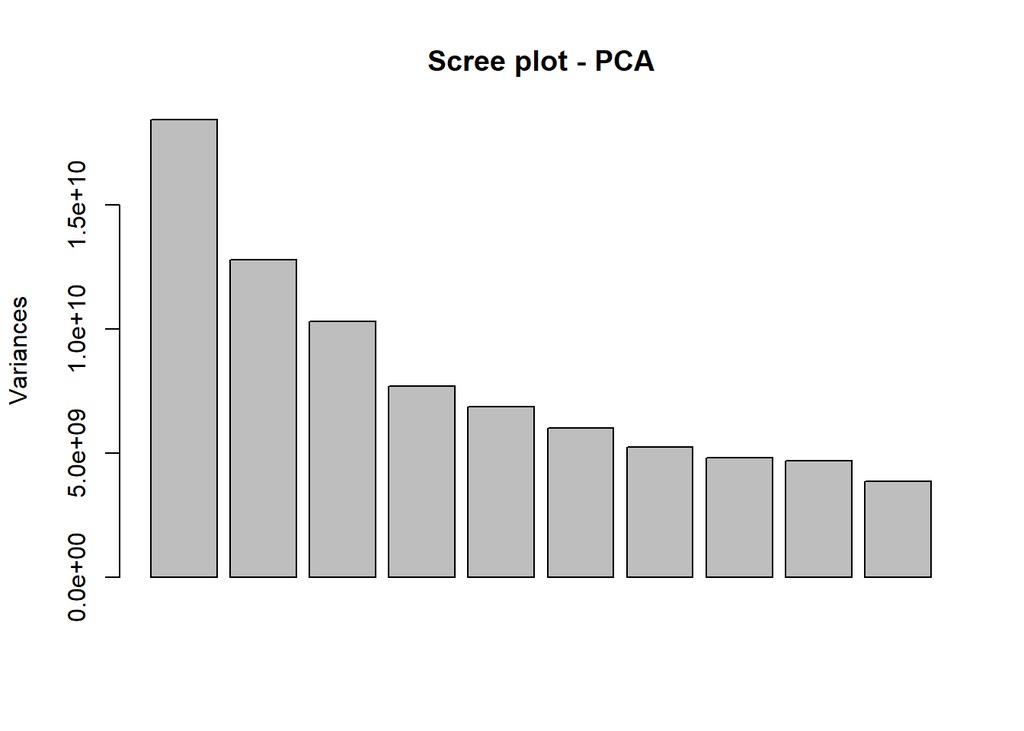

```r
# Scree plot
plot(pcares, main = "Scree plot - PCA")
```

[figure not shown]

```r
biplot(pcares, main = "Biplot PCA - PC1 vs PC2")
```

Visualizando os dois primeiros componentes, avaliamos a possível separação entre grupos de pacientes com base em variáveis clínicas:

### PCA - Estado Vital

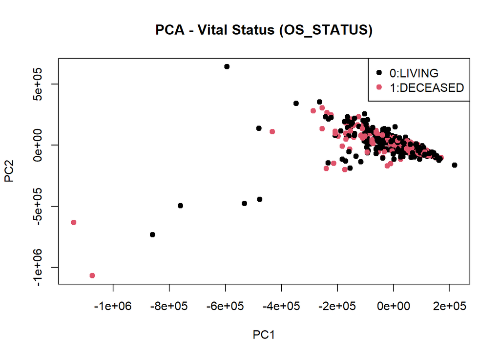

```r
# Converter variáveis de interesse em fatores
# Usar a variável correta: OS_STATUS
amostras_metadados_limpo$vital_status <- factor(amostras_metadados_limpo$OS_STATUS)
cores_vital <- as.integer(amostras_metadados_limpo$vital_status)

# Plot PCA com cores por vital status
plot(pcares$x[,1:2], col=cores_vital, pch=19,
     main="PCA - Vital Status (OS_STATUS)", xlab="PC1", ylab="PC2")
legend("topright", legend=levels(amostras_metadados_limpo$vital_status),
       col=1:length(levels(amostras_metadados_limpo$vital_status)), pch=19)
```

### PCA - Estágio de cancro

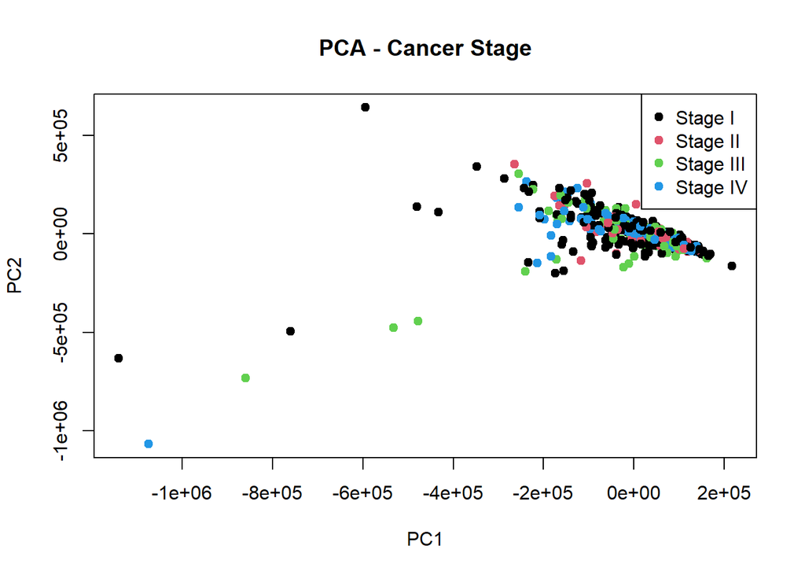

```r
# Usar a variável correta: AJCC_PATHOLOGIC_TUMOR_STAGE
amostras_metadados_limpo$AJCC_PATHOLOGIC_TUMOR_STAGE <- factor(amostras_metadados_limpo$AJCC_PATHOLOGIC_TUMOR_STAGE)
cores_stage <- as.integer(amostras_metadados_limpo$AJCC_PATHOLOGIC_TUMOR_STAGE)

# Plot PCA com cores por AJCC_PATHOLOGIC_TUMOR_STAGE
plot(pcares$x[,1:2], col=cores_stage, pch=19,
     main="PCA - Cancer Stage", xlab="PC1", ylab="PC2")
legend("topright", legend=levels(amostras_metadados_limpo$AJCC_PATHOLOGIC_TUMOR_STAGE),
       col=1:length(levels(amostras_metadados_limpo$AJCC_PATHOLOGIC_TUMOR_STAGE)), pch=19)
```

### PCA - Sexo

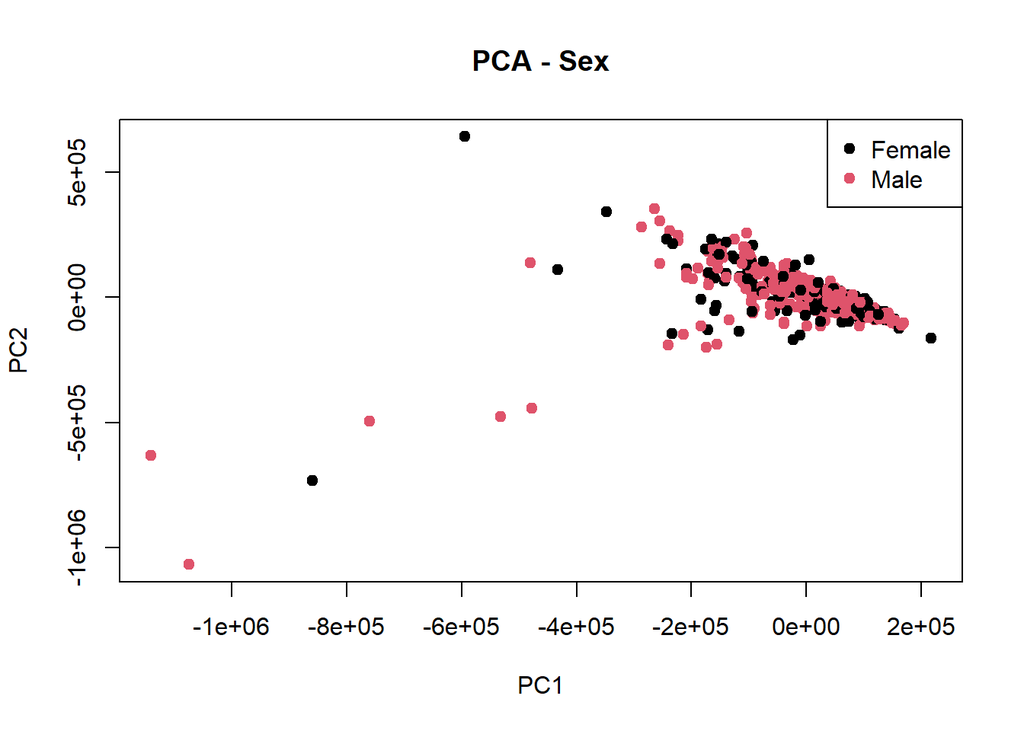

```r
# Usar a variável correta: SEX
amostras_metadados_limpo$SEX <- factor(amostras_metadados_limpo$SEX)
cores_sex <- as.integer(amostras_metadados_limpo$SEX)

# Plot PCA com cores por AJCC_PATHOLOGIC_TUMOR_STAGE
plot(pcares$x[,1:2], col=cores_sex, pch=19,
     main="PCA - Sex", xlab="PC1", ylab="PC2")
legend("topright", legend=levels(amostras_metadados_limpo$SEX),
       col=1:length(levels(amostras_metadados_limpo$SEX)), pch=19)
```

## 6.2 tSNE

### tSNE - Estado Vital

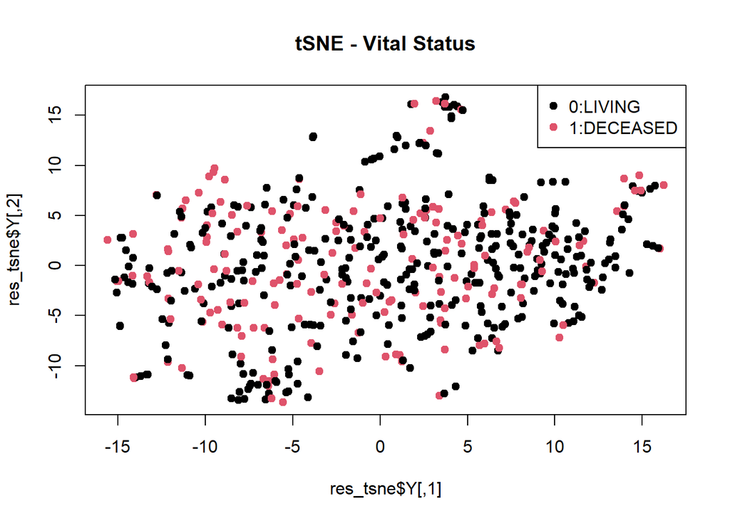

```r
library(Rtsne)

# Remover duplicados para tSNE
dados_pca_nd <- dados_pca[!duplicated(dados_pca), ]

# Executar tSNE
set.seed(123)
res_tsne <- Rtsne(dados_pca_nd, dims = 2, perplexity = 30)

# Plot tSNE - vital status
plot(res_tsne$Y, col=cores_vital, pch=19,
     main="tSNE - Vital Status")
legend("topright", legend=levels(amostras_metadados_limpo$vital_status),
       col=1:length(levels(amostras_metadados_limpo$vital_status)),pch=19)
```

### tSNE - Estágio de cancro

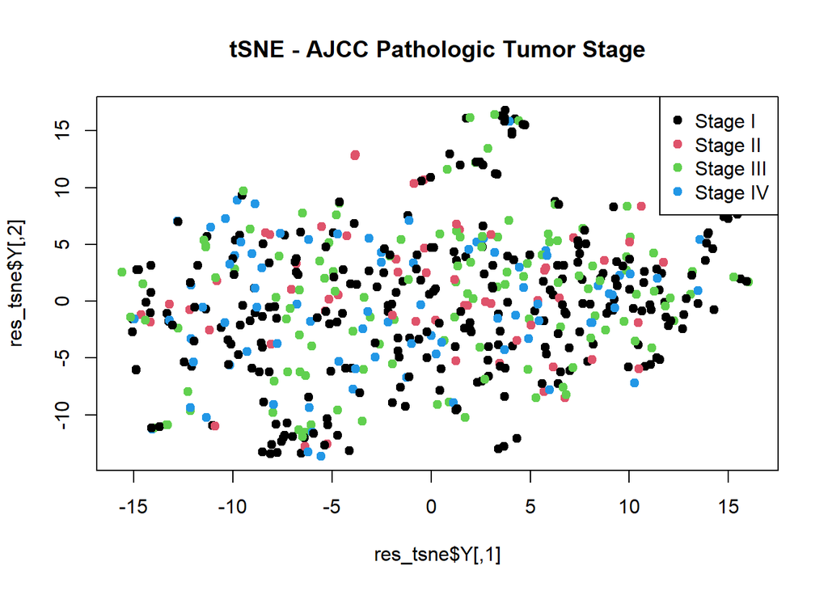

```r
# Executar tSNE
plot(res_tsne$Y, col=cores_stage, pch=19,
     main="tSNE - AJCC Pathologic Tumor Stage")
legend("topright", legend=levels(amostras_metadados_limpo$AJCC_PATHOLOGIC_TUMOR_STAGE),
       col=1:length(levels(amostras_metadados_limpo$AJCC_PATHOLOGIC_TUMOR_STAGE)), pch=19)
```

### tSNE - Sexo

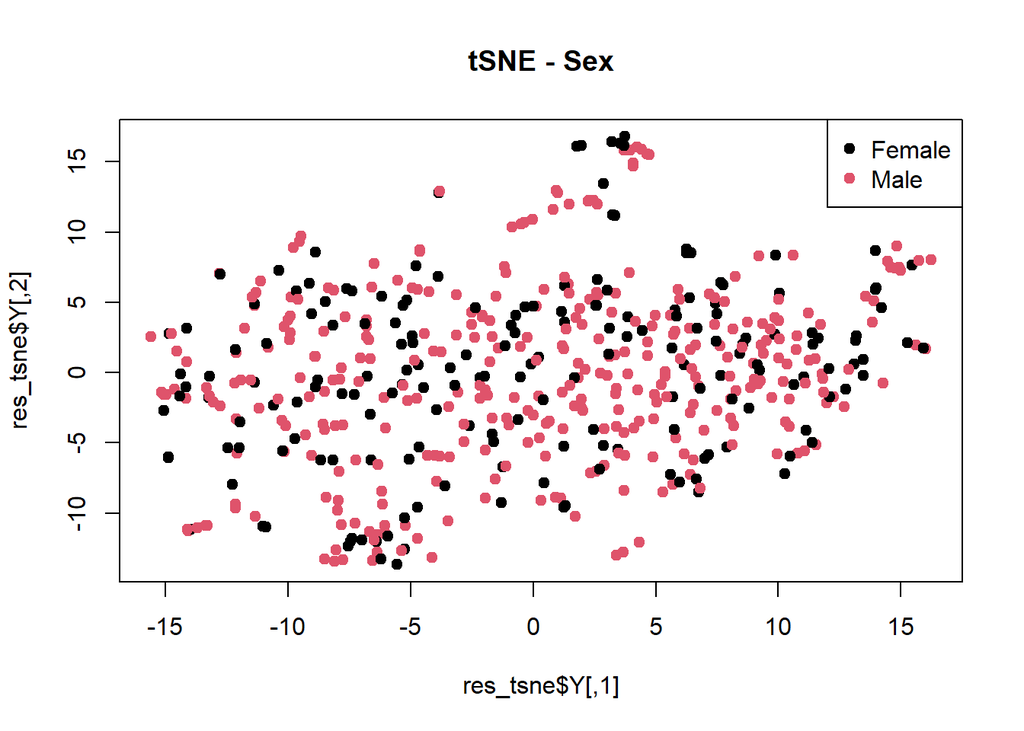

```r
# Plot tSNE - vital status
plot(res_tsne$Y, col=cores_sex, pch=19,
     main="tSNE - Sex")
legend("topright", legend=levels(amostras_metadados_limpo$SEX),
       col=1:length(levels(amostras_metadados_limpo$SEX)),pch=19)
```

Chegamos à mesma conclusão tanto no tSNE como no PCA, de que não ha uma clara separação entre os grupos, tanto quanto ao estágio de cancro, ao estado vital e ao sexo.

# 7. Clustering

## 7.1 Preparação dos dados

```r
# Normalização com vst
vsd <- vst(dds)

#Matriz normalizada
data_rna_KIRC_matrix = as.matrix(assay(vsd))
data_rna_KIRC_transposed = t(data_rna_KIRC_matrix)
```

## 7.2 Clustering Hierárquico

Por genes:

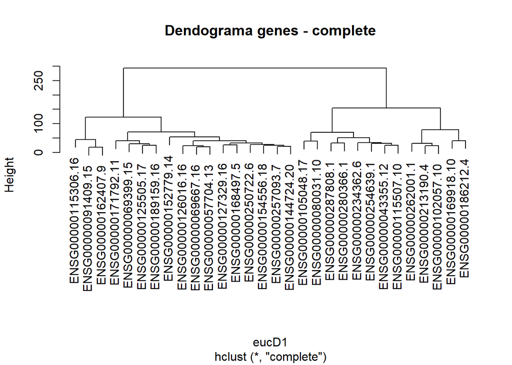

```r
tt_mdr_g = rowttests(data_rna_KIRC_matrix, factor(colData(dds)$vital_status))
rank_de_mdr_g = order(tt_mdr_g$p.value)
genes_de_mdr_g = rank_de_mdr_g[1:30]
data_rna_KIRC_rank = data_rna_KIRC_matrix[genes_de_mdr_g, ]

eucD1 = dist(data_rna_KIRC_rank)

cl.hier4 = hclust(eucD1)
plot(cl.hier4, main="Dendograma genes - complete")
```

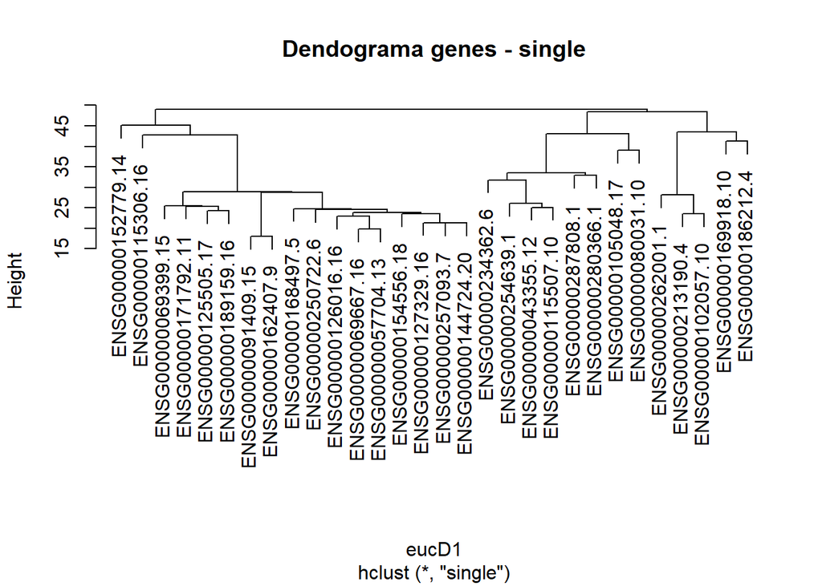

```r
cl.hier5 = hclust(eucD1, method="single")
plot(cl.hier5, main="Dendograma genes - single")
```

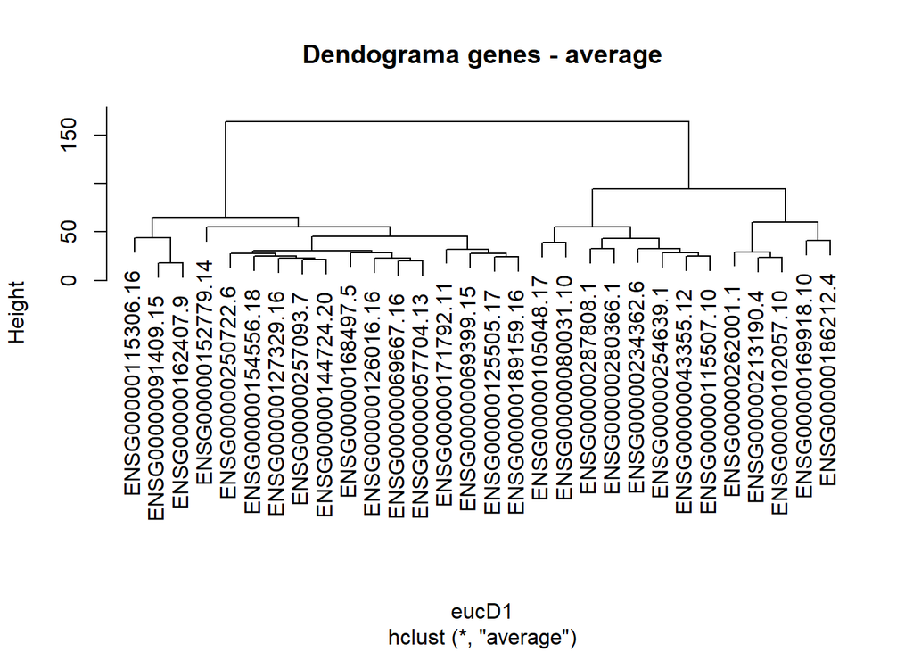

```r
cl.hier6 = hclust(eucD1, method="average")
plot(cl.hier6, main="Dendograma genes - average")
```

```r
#cophenetic
coph_complete <- cophenetic(cl.hier4)
coph_average  <- cophenetic(cl.hier5)
coph_single   <- cophenetic(cl.hier6)

#correlações
cor_comp_av   <- cor(coph_complete, coph_average)
cor_comp_sing <- cor(coph_complete, coph_single)
cor_av_sing   <- cor(coph_average,  coph_single)

cat("complete vs average :", round(cor_comp_av, 3), "\n")
```

```
## complete vs average : 0.824
```

```r
cat("complete vs single  :", round(cor_comp_sing, 3), "\n")
```

```
## complete vs single  : 0.997
```

```r
cat("average vs single   :", round(cor_av_sing, 3), "\n")
```

```
## average vs single   : 0.851
```

- Correlação forte.
- Dendrogramas semelhantes, mas não idênticos.
- Ambos captam bem a estrutura dos dados, com diferenças leves na forma dos clusters.
- Mostra que os agrupamentos são razoavelmente estáveis entre métodos.

- Correlação forte.
- Clusters parecidos, com ligeiras variações.
- Confirma consistência geral dos agrupamentos.

Todos os métodos produzem dendrogramas muito similares, o que valida a robustez dos clusters de genes.

## 7.3 K-means

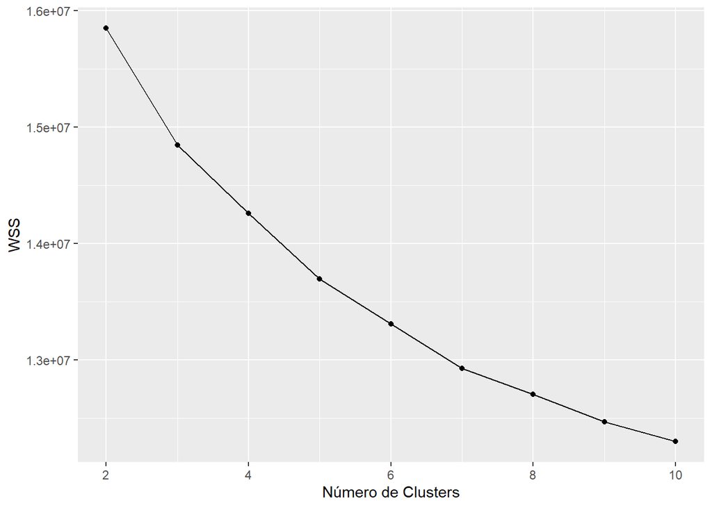

```r
ofs = c()
for (k in 2:10) {
  km = kmeans(data_rna_KIRC_transposed, centers = k, nstart = 10)
  ofs = c(ofs, km$tot.withinss)
}
plot_data = data.frame(num_clusters = 2:10, wss = ofs)

ggplot(plot_data, aes(x = num_clusters, y = wss)) +
  geom_line() +
  geom_point() +
  labs(x = "Número de Clusters", y = "WSS")
```

Atravez do metodo do cotovelo, tanto k=4 como k=5 eram bons candidatos, escolhemos portanto o k=4:

```r
resKmeans = kmeans(data_rna_KIRC_transposed, centers = 4)
centroides = resKmeans$cluster
table(centroides, colData(dds)$vital_status)
```

```
##
## centroides Alive Dead
##          1   120   50
##          2    63   32
##          3   181   44
##          4    48   76
```

# 8. Análise supervisionada (Machine learning)

Preparação dos dados:

```r
set.seed(123456)

# Extrair matriz de expressão normalizada
rna_data <- data.frame(assay(vsd))

# Ordenar resultados do DESeq2 por p-valor
res <- results(dds)
filtered_results_ord <- res[order(res$pvalue), ]

# Combinar expressão com rótulo (vital status)
rna_data_vital_status <- as.data.frame(cbind(
  vital = colData(dds)$vital_status,
  t(rna_data)
))
rna_data_vital_status$vital <- as.factor(rna_data_vital_status$vital)

# Filtrar para os 1000 genes mais diferenciais
de_genes <- rownames(head(filtered_results_ord, 1000))
rna_data_filtered <- rna_data_vital_status[, c("vital", de_genes)]

# Dividir em treino (70%) e teste (30%)
idx <- sample(2, nrow(rna_data_filtered), replace = TRUE, prob = c(0.7, 0.3))
data_set_treino <- rna_data_filtered[idx == 1, ]
dataset_teste <- rna_data_filtered[idx == 2, ]

# Ajustar os níveis para nomes válidos
levels(data_set_treino$vital) <- make.names(levels(data_set_treino$vital))
levels(dataset_teste$vital) <- make.names(levels(dataset_teste$vital))  # ADICIONEI para evitar erro no test set

# Criar folds para cross-validation (10-fold)
folds <- caret::createFolds(data_set_treino$vital, k = 10)
cv_control <- trainControl(
  method = "cv", number = 10, index = folds,
  savePredictions = "final", classProbs = TRUE
)
```

## **Modelo N-Nearest Neighbors**

```r
set.seed(123)

# Treinar modelo kNN
knn_model <- train(
  vital ~ .,
  data = data_set_treino[, c("vital", de_genes)],
  method = "knn",
  tuneGrid = expand.grid(k = seq(3, 15, by = 2)),
  trControl = cv_control,
  preProcess = c("center", "scale")
)

# Resultados
print(knn_model)
```

```
## k-Nearest Neighbors
##
##  430 samples
## 1000 predictors
##    2 classes: 'X1', 'X2'
##
## Pre-processing: centered (1000), scaled (1000)
## Resampling: Cross-Validated (10 fold)
## Summary of sample sizes: 43, 43, 43, 43, 44, 43, ...
## Resampling results across tuning parameters:
##
##   k   Accuracy   Kappa
##    3  0.6940493  0.2523535
##    5  0.7064618  0.2550684
##    7  0.7126534  0.2482195
##    9  0.7141958  0.2425097
##   11  0.7108326  0.2182533
##   13  0.7005026  0.1800642
##   15  0.6945622  0.1530090
##
## Accuracy was used to select the optimal model using the largest value.
## The final value used for the model was k = 9.
```

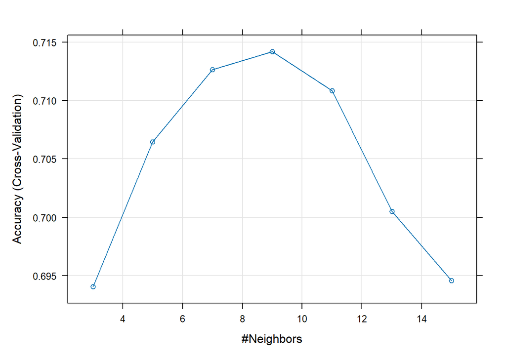

```r
plot(knn_model)
```

```r
pred_knn <- predict(knn_model, newdata = dataset_teste[, c("vital", de_genes)])
confusionMatrix(pred_knn, dataset_teste$vital)
```

```
## Confusion Matrix and Statistics
##
##           Reference
## Prediction  X1  X2
##         X1 117  32
##         X2  11  24
##
##                Accuracy : 0.7663
##                  95% CI : (0.6984, 0.8254)
##     No Information Rate : 0.6957
##     P-Value [Acc > NIR] : 0.020701
##
##                   Kappa : 0.383
##
##  Mcnemar's Test P-Value : 0.002289
##
##             Sensitivity : 0.9141
##             Specificity : 0.4286
##          Pos Pred Value : 0.7852
##          Neg Pred Value : 0.6857
##              Prevalence : 0.6957
##          Detection Rate : 0.6359
##    Detection Prevalence : 0.8098
##       Balanced Accuracy : 0.6713
##
##        'Positive' Class : X1
##
```

- Accuracy geral: 76.6% — razoável para um problema de alta dimensionalidade como expressão gênica.
- Kappa: 0.38 — Um valor de Kappa entre 0.2 e 0.4 é geralmente considerado de acordo baixo/modesto. Isso indica que o modelo tem uma capacidade limitada de fazer previsões melhores do que o acaso.
- Sensitivity (X1): 91.4% — o modelo está ótimo para detectar classe X1 ( “vivo”).
- Specificity (X2): 42.9% — o modelo tem dificuldade para identificar a classe X2 (“morto”).
- Mcnemar’s Test p = 0.002289: indica que o modelo tende a errar de forma desigual entre as classes, o que confirma o viés na predição (favorecendo X1).

## Modelo Random Forest

```r
set.seed(123)

rf_model <- train(
  vital ~ .,
  data = data_set_treino[, c("vital", de_genes)],
  method = "rf",
  trControl = cv_control,
  preProcess = c("center", "scale"),
  tuneLength = 10
)

print(rf_model)
```

```
## Random Forest
##
##  430 samples
## 1000 predictors
##    2 classes: 'X1', 'X2'
##
## Pre-processing: centered (1000), scaled (1000)
## Resampling: Cross-Validated (10 fold)
## Summary of sample sizes: 43, 43, 43, 43, 44, 43, ...
## Resampling results across tuning parameters:
##
##   mtry  Accuracy   Kappa
##      2  0.7307413  0.3258466
##      3  0.7302318  0.3306494
##      7  0.7273841  0.3315908
##     15  0.7279136  0.3399930
##     31  0.7261028  0.3389229
##     63  0.7281753  0.3464715
##    125  0.7284351  0.3525039
##    251  0.7261075  0.3433897
##    501  0.7232678  0.3410096
##   1000  0.7219798  0.3403881
##
## Accuracy was used to select the optimal model using the largest value.
## The final value used for the model was mtry = 2.
```

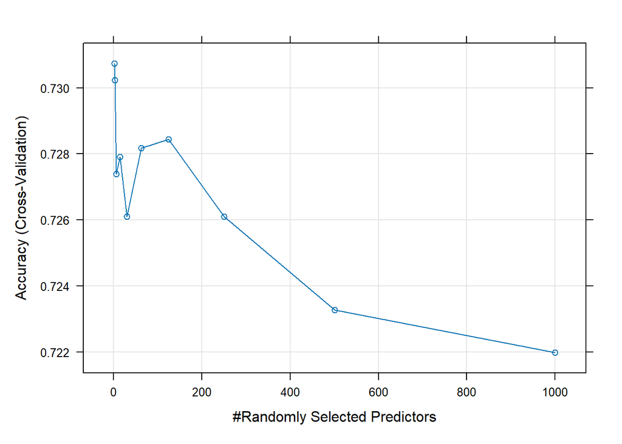

```r
plot(rf_model)
```

```r
# Avaliar no conjunto de teste
pred_rf <- predict(rf_model, newdata = dataset_teste[, c("vital", de_genes)])
confusionMatrix(pred_rf, dataset_teste$vital)
```

```
## Confusion Matrix and Statistics
##
##           Reference
## Prediction  X1  X2
##         X1 117  37
##         X2  11  19
##
##                Accuracy : 0.7391
##                  95% CI : (0.6694, 0.801)
##     No Information Rate : 0.6957
##     P-Value [Acc > NIR] : 0.113740
##
##                   Kappa : 0.2914
##
##  Mcnemar's Test P-Value : 0.000308
##
##             Sensitivity : 0.9141
##             Specificity : 0.3393
##          Pos Pred Value : 0.7597
##          Neg Pred Value : 0.6333
##              Prevalence : 0.6957
##          Detection Rate : 0.6359
##    Detection Prevalence : 0.8370
##       Balanced Accuracy : 0.6267
##
##        'Positive' Class : X1
##
```

```r
set.seed(123)

svm_model <- train(
  vital ~ .,
  data = data_set_treino[, c("vital", de_genes)],
  method = "svmRadial",
  preProcess = c("center", "scale"),
  trControl = cv_control,
  tuneLength = 10
)

print(svm_model)
```

```
## Support Vector Machines with Radial Basis Function Kernel
##
##  430 samples
## 1000 predictors
##    2 classes: 'X1', 'X2'
##
## Pre-processing: centered (1000), scaled (1000)
## Resampling: Cross-Validated (10 fold)
## Summary of sample sizes: 43, 43, 43, 43, 44, 43, ...
## Resampling results across tuning parameters:
##
##   C       Accuracy   Kappa
##     0.25  0.6868142  0.1880794
##     0.50  0.6955857  0.2066832
##     1.00  0.7025584  0.2427474
##     2.00  0.6893988  0.1966804
##     4.00  0.6800945  0.1650532
##     8.00  0.6826651  0.1497951
##    16.00  0.6736425  0.1231886
##    32.00  0.6808870  0.1633827
##    64.00  0.6751641  0.1522407
##   128.00  0.6793213  0.1282615
##
## Tuning parameter 'sigma' was held constant at a value of 0.0007347638
## Accuracy was used to select the optimal model using the largest value.
## The final values used for the model were sigma = 0.0007347638 and C = 1.
```

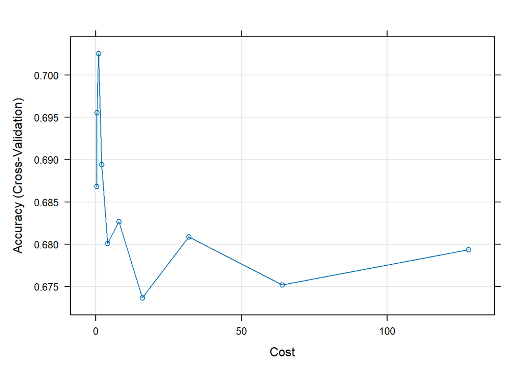

```r
plot(svm_model)
```

```r
# Avaliar no conjunto de teste
pred_svm <- predict(svm_model, newdata = dataset_teste[, c("vital", de_genes)])
confusionMatrix(pred_svm, dataset_teste$vital)
```

```
## Confusion Matrix and Statistics
##
##           Reference
## Prediction  X1  X2
##         X1 117  38
##         X2  11  18
##
##                Accuracy : 0.7337
##                  95% CI : (0.6637, 0.796)
##     No Information Rate : 0.6957
##     P-Value [Acc > NIR] : 0.1485849
##
##                   Kappa : 0.2724
##
##  Mcnemar's Test P-Value : 0.0002038
##
##             Sensitivity : 0.9141
##             Specificity : 0.3214
##          Pos Pred Value : 0.7548
##          Neg Pred Value : 0.6207
##              Prevalence : 0.6957
##          Detection Rate : 0.6359
##    Detection Prevalence : 0.8424
##       Balanced Accuracy : 0.6177
##
##        'Positive' Class : X1
##
```

- Accuracy: 73.37% – A precisão do SVM é quase idêntica à do Random Forest e do kNN, sugerindo desempenho semelhante em termos de acerto geral.
- Kappa: 0.2724 – O valor de Kappa é ligeiramente inferior ao do Random Forest e inferior tambem ao do kNN (0.38), o que indica um pior alinhamento com a classificação verdadeira.
- Sensitivity (X1): 91.4% – A sensibilidade é igual à do kNN, muito boa para identificar a classe X1 (vivos).
- Specificity (X2): 32.1% – Pior que o Random Forest e que a do kNN , o que mostra desempenho ligeiramente inferior na detecção da classe X2 (mortos).
- Mcnemar’s Test p = 0.0002038– Tal como no RF, o p-valor indica uma distorção significativa nas predições, a maior dos 3 modelos, com tendência a favorecer a classe majoritária (X1).